# Cok Degiskenli Istatistiksel Yontemler

Github: ozgurnrttn

# Önsöz

Ödev kapsamında incelenen kişilerin kredi kartı kullanım verileri  
Veri setinin orjinal haline [Buradan](https://statlearning.com/data.html) ulaşabilirsiniz.

[Github](https://github.com/ozgurnrttn)

Değişken Tanımları;

[output not shown]

Verinin yapısı ile ilgili bilgiler;

• Veride 11 değişken vardır.

1. 6 adet scaler değişken,
2. 4 adet nominal değişken,
3. 1 adet ordinal değişken vardır.

• Veri 400 gözlemden oluşmaktadır.

```r
library("haven")
library("tidyverse")
library("fBasics")
library("dplyr")
library("biotools")
```

```r
library("car")
library("gplots")
library("rstatix")
library("broom")
library("heplots")
library("gplots")
```

```r
kredi <- read_sav("C:/Users/oztur/OneDrive/Masaüstü/credit.sav")
kredi = as.data.frame(kredi)
kredi$Ethnicity<-factor(kredi$Ethnicity,levels = c(0,1,2),labels=c("Asian","Caucasian","African American"))
kredi$Gender<-factor(kredi$Gender,levels = c(0,1),labels=c("Kadin","Erkek"))
kredi$Student<-factor(kredi$Student,levels = c(0,1),labels=c("Ogrenci Degil","Ogrenci"))
kredi$Married<-factor(kredi$Married,levels = c(0,1),labels=c("Bekar","Evli"))
kredi$Education = as.ordered(kredi$Education)
glimpse(kredi)
```

```
## Rows: 400
## Columns: 12
## $ Income    <dbl> 14.891, 106.025, 104.593, 148.924, 55.882, 80.180, 20.996...
## $ Limit     <dbl> 3606, 6645, 7075, 9504, 4897, 8047, 3388, 7114, 3300, 681...
## $ Rating    <dbl> 283, 483, 514, 681, 357, 569, 259, 512, 266, 491, 589, 13...
## $ Cards     <dbl> 2, 3, 4, 3, 2, 4, 2, 2, 5, 3, 4, 3, 1, 1, 2, 3, 3, 3, 1, ...
## $ Age       <dbl> 34, 82, 71, 36, 68, 77, 37, 87, 66, 41, 30, 64, 57, 49, 7...
## $ Education <ord> 11, 15, 11, 11, 16, 10, 12, 9, 13, 19, 14, 16, 7, 9, 13, ...
## $ Gender    <fct> Erkek, Kadin, Erkek, Kadin, Erkek, Erkek, Kadin, Erkek, K...
## $ Student   <fct> Ogrenci Degil, Ogrenci, Ogrenci Degil, Ogrenci Degil, Ogr...
## $ Married   <fct> Evli, Evli, Bekar, Bekar, Evli, Bekar, Bekar, Bekar, Beka...
## $ Ethnicity <fct> Caucasian, Asian, Asian, Asian, Caucasian, Caucasian, Afr...
## $ Balance   <dbl> 333, 903, 580, 964, 331, 1151, 203, 872, 279, 1350, 1407,...
## $ Kredi_ID  <dbl> 1, 2, 3, 4, 5, 6, 7, 8, 9, 10, 11, 12, 13, 14, 15, 16, 17...
```

```r
summary(kredi)
```

```
##      Income           Limit           Rating          Cards
##  Min.   : 10.35   Min.   :  855   Min.   : 93.0   Min.   :1.000
##  1st Qu.: 21.01   1st Qu.: 3088   1st Qu.:247.2   1st Qu.:2.000
##  Median : 33.12   Median : 4622   Median :344.0   Median :3.000
##  Mean   : 45.22   Mean   : 4736   Mean   :354.9   Mean   :2.958
##  3rd Qu.: 57.47   3rd Qu.: 5873   3rd Qu.:437.2   3rd Qu.:4.000
##  Max.   :186.63   Max.   :13913   Max.   :982.0   Max.   :9.000
##
##       Age          Education     Gender             Student     Married
##  Min.   :23.00   16     : 50   Kadin:207   Ogrenci Degil:360   Bekar:155
##  1st Qu.:41.75   15     : 49   Erkek:193   Ogrenci      : 40   Evli :245
##  Median :56.00   14     : 48
##  Mean   :55.67   13     : 38
##  3rd Qu.:70.00   12     : 37
##  Max.   :98.00   17     : 34
##                  (Other):144
##             Ethnicity      Balance           Kredi_ID
##  Asian           :102   Min.   :   0.00   Min.   :  1.0
##  Caucasian       :199   1st Qu.:  68.75   1st Qu.:100.8
##  African American: 99   Median : 459.50   Median :200.5
##                         Mean   : 520.01   Mean   :200.5
##                         3rd Qu.: 863.00   3rd Qu.:300.2
##                         Max.   :1999.00   Max.   :400.0
##
```

Verinin tanımsal istatistikleri

```r
as_tibble(kredi)
```

| Income | Limit | Rating | Cards | Age | Education | Gender | Student | Married | Ethnicity | Balance | Kredi_ID |
| --- | --- | --- | --- | --- | --- | --- | --- | --- | --- | --- | --- |
| 14.891 | 3606 | 283 | 2 | 34 | 11 | Erkek | Ogrenci Degil | Evli | Caucasian | 333 | 1 |
| 106.025 | 6645 | 483 | 3 | 82 | 15 | Kadin | Ogrenci | Evli | Asian | 903 | 2 |
| 104.593 | 7075 | 514 | 4 | 71 | 11 | Erkek | Ogrenci Degil | Bekar | Asian | 580 | 3 |
| 148.924 | 9504 | 681 | 3 | 36 | 11 | Kadin | Ogrenci Degil | Bekar | Asian | 964 | 4 |
| 55.882 | 4897 | 357 | 2 | 68 | 16 | Erkek | Ogrenci Degil | Evli | Caucasian | 331 | 5 |
| 80.180 | 8047 | 569 | 4 | 77 | 10 | Erkek | Ogrenci Degil | Bekar | Caucasian | 1151 | 6 |
| 20.996 | 3388 | 259 | 2 | 37 | 12 | Kadin | Ogrenci Degil | Bekar | African American | 203 | 7 |
| 71.408 | 7114 | 512 | 2 | 87 | 9 | Erkek | Ogrenci Degil | Bekar | Asian | 872 | 8 |
| 15.125 | 3300 | 266 | 5 | 66 | 13 | Kadin | Ogrenci Degil | Bekar | Caucasian | 279 | 9 |
| 71.061 | 6819 | 491 | 3 | 41 | 19 | Kadin | Ogrenci | Evli | African American | 1350 | 10 |

[output cut: 390 more lines]

Verinin gösterimi

# 1. Normallik

## 1. Degişkenlerin Normallik Varsayımlarının kontrolü

```r
kredi %>%
  dplyr::select(Income, Limit, Rating,Cards, Age, Balance) %>%
  mshapiro_test()
```

| statistic | p.value |
| --- | --- |
| 0.9273235 | 5.05036e-13 |

$H_A$: Veri Seti Normal Dağılmaktadır.

Bütün değişkenlerin sig. değeri 0,05’ten küçük olduğu için $H_0$ reddedilir.

%95 Güven düzeyinde değişkenler normal dağılımdan gelmemektedir.

```r
shapiroTest(kredi$Income)
```

```
##
## Title:
##  Shapiro - Wilk Normality Test
##
## Test Results:
##   STATISTIC:
##     W: 0.8097
##   P VALUE:
##     < 2.2e-16
##
## Description:
##  Fri Jan 29 15:56:38 2021 by user: Reddithun
```

$H_A$: Gelir Değişkeni Normal Dağılmaktadır.

Bütün değişkenlerin sig. değeri 0,05’ten küçük olduğu için $H_0$ reddedilir.

%95 Güven düzeyinde gelir değişkeni normal dağılımdan gelmemektedir.

```r
shapiroTest(kredi$Limit)
```

```
##
## Title:
##  Shapiro - Wilk Normality Test
##
## Test Results:
##   STATISTIC:
##     W: 0.9574
##   P VALUE:
##     2.374e-09
##
## Description:
##  Fri Jan 29 15:56:38 2021 by user: Reddithun
```

$H_A$: Limit Değişkeni Normal Dağılmaktadır.

Bütün değişkenlerin sig. değeri 0,05’ten küçük olduğu için $H_0$ reddedilir.

%95 Güven düzeyinde limit değişkeni normal dağılımdan gelmemektedir.

```r
shapiroTest(kredi$Rating)
```

```
##
## Title:
##  Shapiro - Wilk Normality Test
##
## Test Results:
##   STATISTIC:
##     W: 0.9545
##   P VALUE:
##     8.958e-10
##
## Description:
##  Fri Jan 29 15:56:38 2021 by user: Reddithun
```

$H_A$: Kredi Notu Değişkeni Normal Dağılmaktadır.

Bütün değişkenlerin sig. değeri 0,05’ten küçük olduğu için $H_0$ reddedilir.

%95 Güven düzeyinde kredi notu değişkeni normal dağılımdan gelmemektedir.

```r
shapiroTest(kredi$Cards)
```

```
##
## Title:
##  Shapiro - Wilk Normality Test
##
## Test Results:
##   STATISTIC:
##     W: 0.9145
##   P VALUE:
##     2.838e-14
##
## Description:
##  Fri Jan 29 15:56:38 2021 by user: Reddithun
```

$H_A$: Kart Sayısı Değişkeni Normal Dağılmaktadır.

Bütün değişkenlerin sig. değeri 0,05’ten küçük olduğu için $H_0$ reddedilir.

%95 Güven düzeyinde kart sayisi değişkeni normal dağılımdan gelmemektedir.

```r
shapiroTest(kredi$Balance)
```

```
##
## Title:
##  Shapiro - Wilk Normality Test
##
## Test Results:
##   STATISTIC:
##     W: 0.9175
##   P VALUE:
##     5.344e-14
##
## Description:
##  Fri Jan 29 15:56:38 2021 by user: Reddithun
```

$H_A$: Bakiye Değişkeni Normal Dağılmaktadır.

Bütün değişkenlerin sig. değeri 0,05’ten küçük olduğu için $H_0$ reddedilir.

%95 Güven düzeyinde bakiye değişkeni normal dağılımdan gelmemektedir.

**NOT: NORMALLİK VARSAYIMI SAĞLANDIĞI VARSAYILARAK DEVAM EDİLMİŞTİR.**

## 1.2 Degiskenlerin Grafikleri

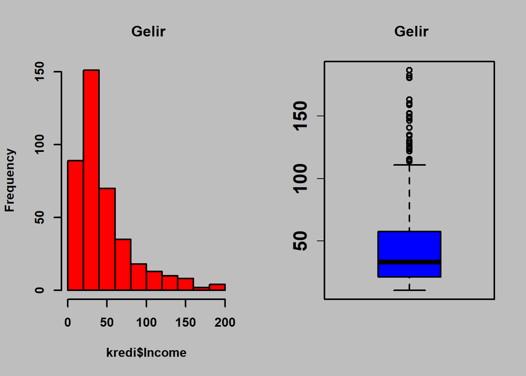

```r
par(mfrow=c(1,2),bg = "grey",lwd=2,font.lab=2,font.axis = 2)

hist(kredi$Income,col = "Red",main=" Gelir", lwd = 2,font.lab=2,font.axis =
2)
boxplot(kredi$Income,col = "Blue",main=" Gelir",lwd=2,cex.axis = 1.5)
```

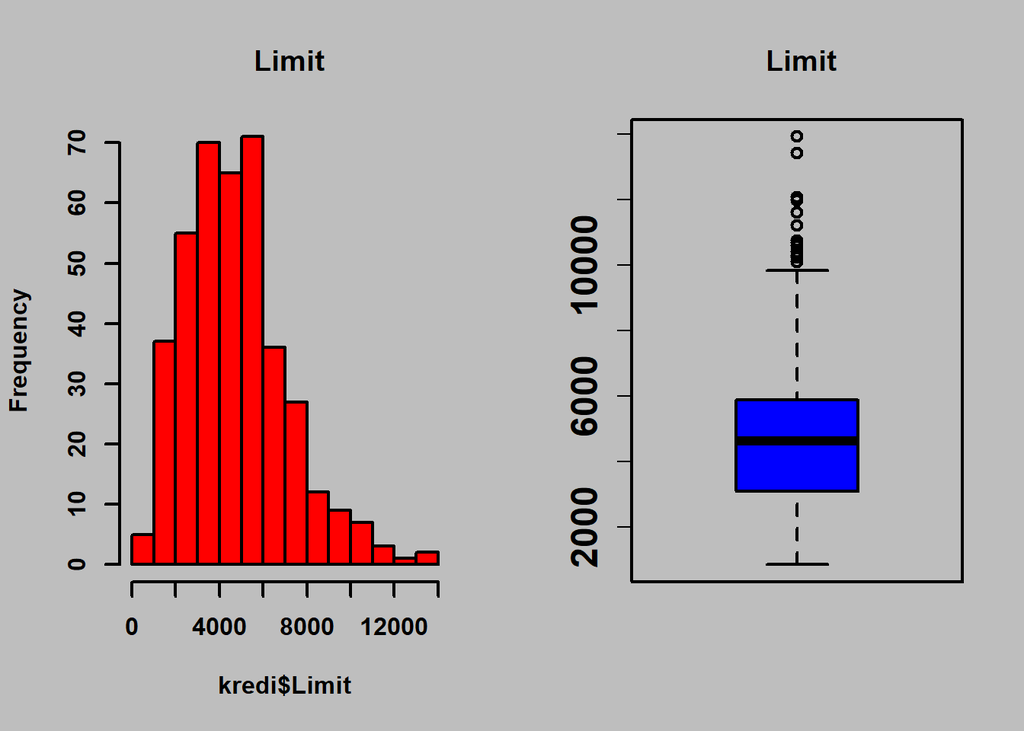

```r
par(mfrow=c(1,2),bg = "grey",lwd=2,font.lab=2,font.axis = 2)

hist(kredi$Limit,col = "Red",main=" Limit", lwd = 2,font.lab=2,font.axis =
2)
boxplot(kredi$Limit,col = "Blue",main=" Limit",lwd=2,cex.axis = 1.5)
```

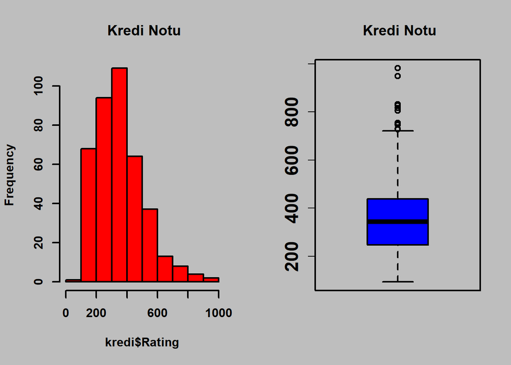

```r
par(mfrow=c(1,2),bg = "grey",lwd=2,font.lab=2,font.axis = 2)

hist(kredi$Rating,col = "Red",main=" Kredi Notu", lwd = 2,font.lab=2,font.axis =
2)
boxplot(kredi$Rating,col = "Blue",main=" Kredi Notu",lwd=2,cex.axis = 1.5)
```

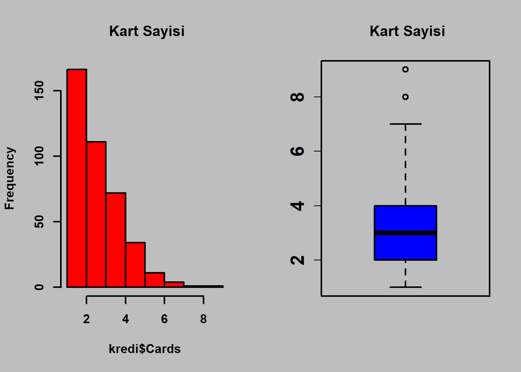

```r
par(mfrow=c(1,2),bg = "grey",lwd=2,font.lab=2,font.axis = 2)

hist(kredi$Cards,col = "Red",main=" Kart Sayısı", lwd = 2,font.lab=2,font.axis =
2)
boxplot(kredi$Cards,col = "Blue",main=" Kart Sayısı",lwd=2,cex.axis = 1.5)
```

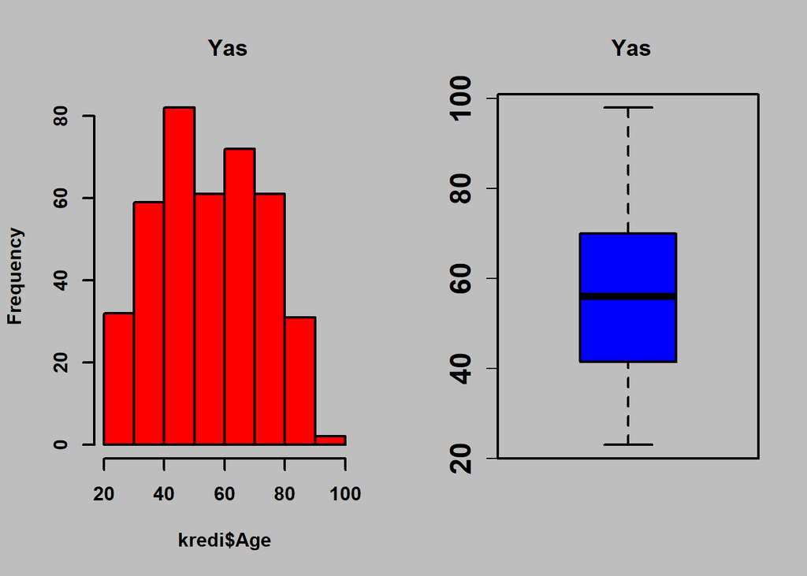

```r
par(mfrow=c(1,2),bg = "grey",lwd=2,font.lab=2,font.axis = 2)

hist(kredi$Age,col = "Red",main=" Yas", lwd = 2,font.lab=2,font.axis =
2)
boxplot(kredi$Age,col = "Blue",main=" Yas",lwd=2,cex.axis = 1.5)
```

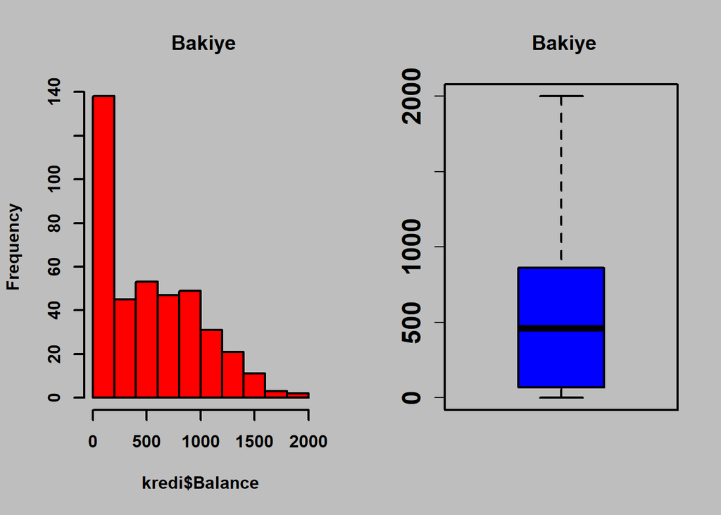

```r
par(mfrow=c(1,2),bg = "grey",lwd=2,font.lab=2,font.axis = 2)

hist(kredi$Balance,col = "Red",main=" Bakiye", lwd = 2,font.lab=2,font.axis =
2)
boxplot(kredi$Balance,col = "Blue",main=" Bakiye",lwd=2,cex.axis = 1.5)
```

# 2. Tek Yölü Manova

## 2.1 Varyans Kovaryans Matrisi Eşitliği

```r
boxM(kredi[,c("Income", "Limit", "Rating", "Cards", "Age","Balance" )], kredi$Ethnicity)
```

```
##
##  Box's M-test for Homogeneity of Covariance Matrices
##
## data:  kredi[, c("Income", "Limit", "Rating", "Cards", "Age", "Balance")]
## Chi-Sq (approx.) = 33.807, df = 42, p-value = 0.8121
```

$H_0$: Gruplara göre varyans-kovaryans matrisi eşittir.

$H_A$: Gruplara göre varyans-kovaryans matrisi eşit değildir.

Sig, değeri 0,05’den büyük olduğu için $H_0$ reddedilmez.

%95 güven düzeyi ile gruplara göre varyans kovaryans matrisi eşittir denilebilir.

## 2.2 Varyansların Homojen Dağılım Testi

```r
leveneTest(Income ~ Ethnicity, data=kredi,center=mean)
```

|  | Df | F value | Pr(>F) |
| --- | --- | --- | --- |
| group | 2 | 1.261488 | 0.284365 |
|  | 397 | NA | NA |

```r
leveneTest(Limit ~ Ethnicity, data=kredi,center=mean)
```

|  | Df | F value | Pr(>F) |
| --- | --- | --- | --- |
| group | 2 | 0.4240002 | 0.6547198 |
|  | 397 | NA | NA |

```r
leveneTest(Rating ~ Ethnicity, data=kredi,center=mean)
```

|  | Df | F value | Pr(>F) |
| --- | --- | --- | --- |
| group | 2 | 0.474743 | 0.6223976 |
|  | 397 | NA | NA |

```r
leveneTest(Cards ~ Ethnicity, data=kredi,center=mean)
```

|  | Df | F value | Pr(>F) |
| --- | --- | --- | --- |
| group | 2 | 2.007593 | 0.1356729 |
|  | 397 | NA | NA |

```r
leveneTest(Age ~ Ethnicity, data=kredi,center=mean)
```

|  | Df | F value | Pr(>F) |
| --- | --- | --- | --- |
| group | 2 | 0.4899358 | 0.6130356 |
|  | 397 | NA | NA |

```r
leveneTest(Balance ~ Ethnicity, data=kredi,center=mean)
```

|  | Df | F value | Pr(>F) |
| --- | --- | --- | --- |
| group | 2 | 1.839137 | 0.1603062 |
|  | 397 | NA | NA |

$H_0$: Varyanslar homejen dağılır.

$H_A$: Varyanslar homojen dağılmaz.

## 2.3 Degiskenlere Göre Ortalamalar ve Ortalama Çizimleri

```r
attach(kredi)
aggregate(kredi[,c(1:5,11)], list(Gender), mean)
```

| Group.1 | Income | Limit | Rating | Cards | Age | Balance |
| --- | --- | --- | --- | --- | --- | --- |
| Kadin | 44.85393 | 4756.517 | 356.2657 | 2.927536 | 55.73430 | 529.5362 |
| Erkek | 45.61032 | 4713.166 | 353.5181 | 2.989637 | 55.59585 | 509.8031 |

```r
aggregate(kredi[,c(1:5,11)], list(Married), mean)
```

| Group.1 | Income | Limit | Rating | Cards | Age | Balance |
| --- | --- | --- | --- | --- | --- | --- |
| Bekar | 43.64109 | 4645.303 | 347.8000 | 2.974194 | 57.25161 | 523.2903 |
| Evli | 46.21708 | 4792.727 | 359.4571 | 2.946939 | 54.66531 | 517.9429 |

```r
aggregate(kredi[,c(1:5,11)], list(Student), mean)
```

| Group.1 | Income | Limit | Rating | Cards | Age | Balance |
| --- | --- | --- | --- | --- | --- | --- |
| Ogrenci Degil | 44.98853 | 4740.222 | 355.0444 | 2.969444 | 55.83889 | 480.3694 |
| Ogrenci | 47.29205 | 4694.000 | 354.0000 | 2.850000 | 54.12500 | 876.8250 |

```r
aggregate(kredi[,c(1:5,11)], list(Ethnicity), mean)
```

| Group.1 | Income | Limit | Rating | Cards | Age | Balance |
| --- | --- | --- | --- | --- | --- | --- |
| Asian | 44.18783 | 4607.824 | 345.4314 | 2.970588 | 53.91176 | 512.3137 |
| Caucasian | 44.52194 | 4728.462 | 354.7739 | 2.949749 | 55.65327 | 518.4975 |
| African American | 47.68210 | 4881.596 | 365.0707 | 2.959596 | 57.50505 | 531.0000 |

Kategorik değişkenlerin sürekle değişkenler üzerinde ortalamaları.

## 2.4 Ethnicity Değişkeninin Ortalama Çizimleri

Aşağıdaki grafiklerde etnik köken değişkeninin sürekli eğişkenler üzerinde ortalama çizimleri yer almaktadır

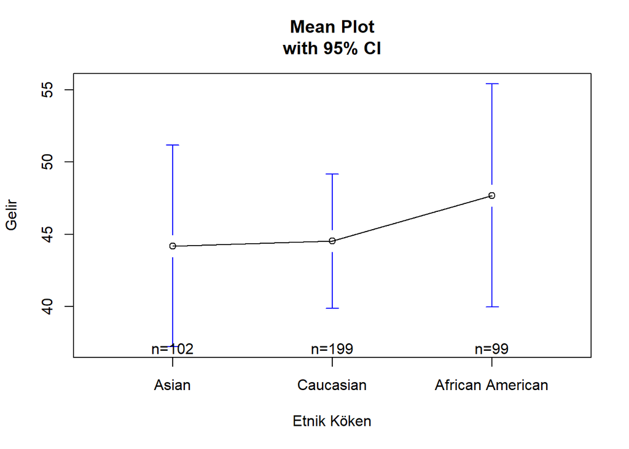

```r
plotmeans(Income~Ethnicity,xlab="Etnik Köken",ylab="Gelir", main="Mean Plot\nwith 95% CI")
```

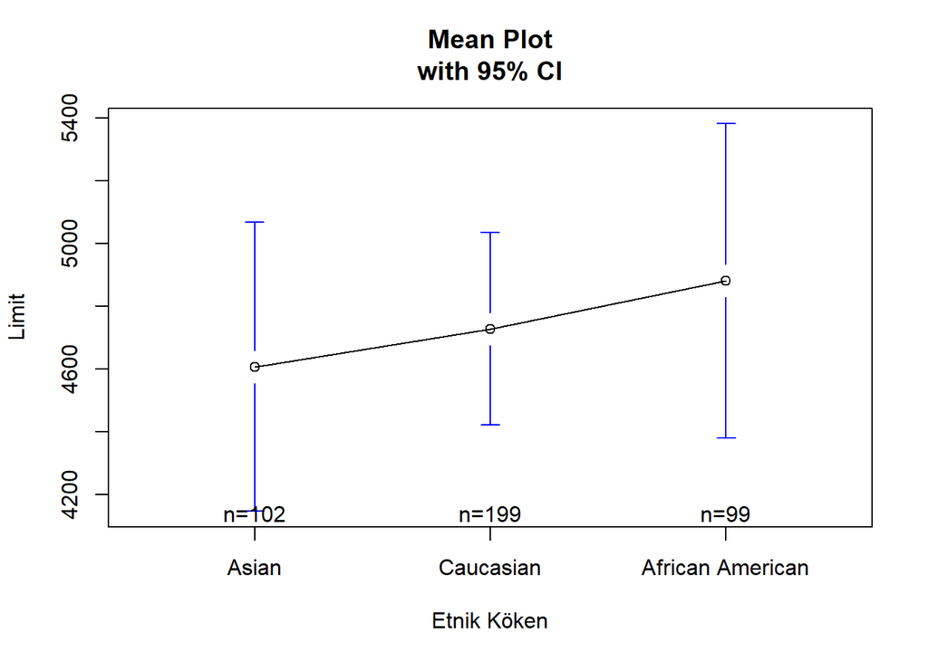

```r
plotmeans(Limit~Ethnicity,xlab="Etnik Köken",ylab="Limit", main="Mean Plot\nwith 95% CI")
```

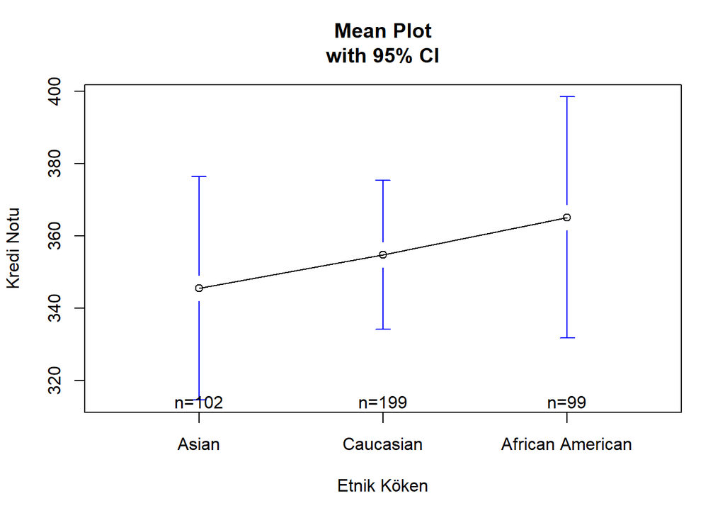

```r
plotmeans(Rating~Ethnicity,xlab="Etnik Köken",ylab="Kredi Notu", main="Mean Plot\nwith 95% CI")
```

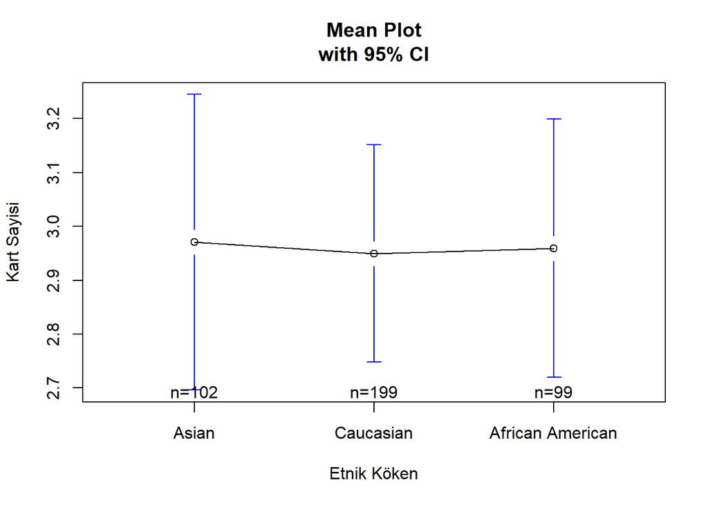

```r
plotmeans(Cards~Ethnicity,xlab="Etnik Köken",ylab="Kart Sayısı", main="Mean Plot\nwith 95% CI")
```

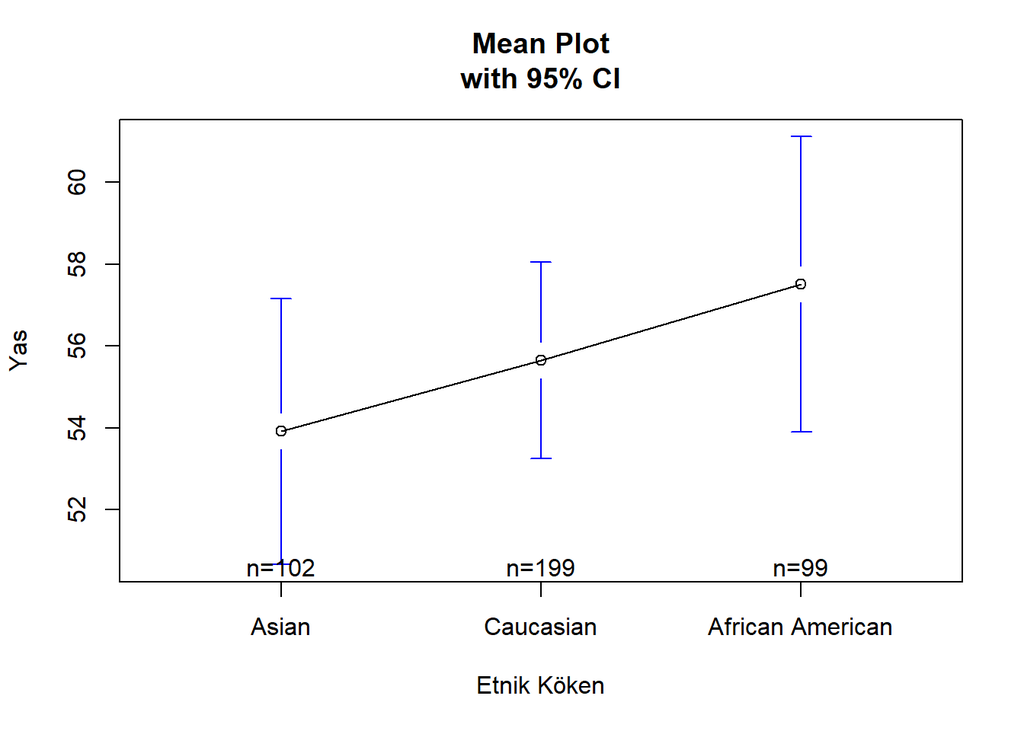

```r
plotmeans(Age~Ethnicity,xlab="Etnik Köken",ylab="Yas", main="Mean Plot\nwith 95% CI")
```

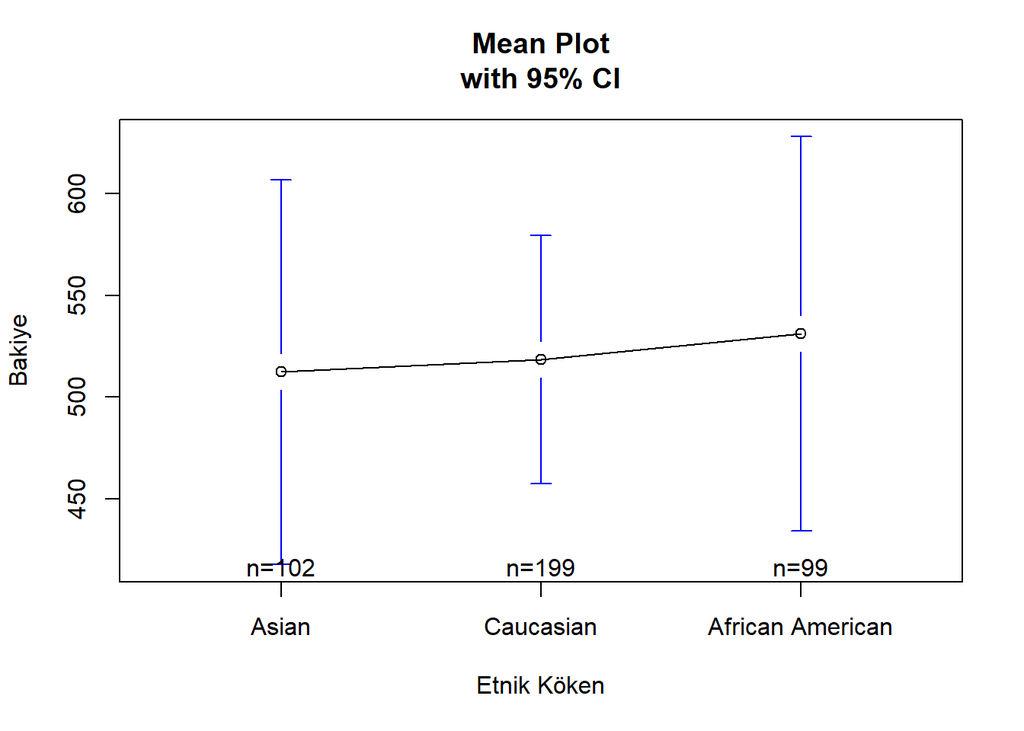

```r
plotmeans(Balance~Ethnicity,xlab="Etnik Köken",ylab="Bakiye", main="Mean Plot\nwith 95% CI")
```

## 2.5. Manova

```r
kredi_manova <- manova(cbind(Income, Limit, Rating, Cards, Age, Balance) ~ Ethnicity,data=kredi)
summary(kredi_manova, test = "Hotelling-Lawley")
```

```
##            Df Hotelling-Lawley approx F num Df den Df Pr(>F)
## Ethnicity   2         0.016096  0.52448     12    782 0.8997
## Residuals 397
```

```r
summary(kredi_manova, test = "Wilks")
```

```
##            Df   Wilks approx F num Df den Df Pr(>F)
## Ethnicity   2 0.98413  0.52461     12    784 0.8997
## Residuals 397
```

```r
summary(kredi_manova, test = "Pillai")
```

```
##            Df   Pillai approx F num Df den Df Pr(>F)
## Ethnicity   2 0.015895  0.52473     12    786 0.8996
## Residuals 397
```

```r
summary(kredi_manova, test = "Roy")
```

```
##            Df      Roy approx F num Df den Df Pr(>F)
## Ethnicity   2 0.014163  0.92768      6    393 0.4748
## Residuals 397
```

$H_A$: Etnik köken diğer bağımlı değişkenlerin ortalamaları üzerinde anlamlı farklılık göstermez.

Wilk’s Lambda Sig, 0,05’ten büyük olduğu için $H_0$ reddedilmez.

## 2.6. Farklılık Yaratan Değişken

```r
summary.aov(kredi_manova)
```

```
##  Response Income :
##              Df Sum Sq Mean Sq F value Pr(>F)
## Ethnicity     2    806  402.88  0.3232  0.724
## Residuals   397 494816 1246.39
##
##  Response Limit :
##              Df     Sum Sq Mean Sq F value Pr(>F)
## Ethnicity     2    3785642 1892821  0.3541  0.702
## Residuals   397 2121999344 5345087
##
##  Response Rating :
##              Df  Sum Sq Mean Sq F value Pr(>F)
## Ethnicity     2   19388  9694.1  0.4037 0.6681
## Residuals   397 9532496 24011.3
##
##  Response Cards :
##              Df Sum Sq Mean Sq F value Pr(>F)
## Ethnicity     2   0.03 0.01493  0.0079 0.9921
## Residuals   397 750.25 1.88979
##
##  Response Age :
##              Df Sum Sq Mean Sq F value Pr(>F)
## Ethnicity     2    649  324.37  1.0906  0.337
## Residuals   397 118076  297.42
##
##  Response Balance :
##              Df   Sum Sq Mean Sq F value Pr(>F)
## Ethnicity     2    18454    9227  0.0434 0.9575
## Residuals   397 84321458  212397
```

$H_0$: Etnik köken değişkenler üzerinde etkili değildir.

$H_A$: Etnik köken değişkenler üzerinde etkilidir.

## 2.7. Çoklu karşılaştırma

$H_0$: İki grup arasında anlamlı farklılıklar yoktur

$H_A$: İki grup arasında anlamlı farklılık vardır

Değişkenin sig. değeri 0.05’den küçük ise $H_0$ reddedilir.

**Değişkenler tektek yorumlanacaktır**

```r
tatmin_aov <- aov(Income ~ Ethnicity, data = kredi)
TukeyHSD(tatmin_aov, "Ethnicity")
```

```
##   Tukey multiple comparisons of means
##     95% family-wise confidence level
##
## Fit: aov(formula = Income ~ Ethnicity, data = kredi)
##
## $Ethnicity
##                                 diff       lwr      upr     p adj
## Caucasian-Asian            0.3341114 -9.779809 10.44803 0.9966757
## African American-Asian     3.4942677 -8.223456 15.21199 0.7627149
## African American-Caucasian 3.1601563 -7.054574 13.37489 0.7471397
```

Asyalıların gelir durumu ile Kasfkasyalılar arasında anlamlı farklılık yok.

Asyalıların gelir durumu ile Afrika ve Amerikalılıar arasında anlamlı farklılık yoktur.

Kasfkasyalıların gelir durumu ile Afrika ve Amerikalılıar arasında anlamlı farklılık yoktur.

```r
tatmin_aov <- aov(Limit ~ Ethnicity, data = kredi)
TukeyHSD(tatmin_aov, "Ethnicity")
```

```
##   Tukey multiple comparisons of means
##     95% family-wise confidence level
##
## Fit: aov(formula = Limit ~ Ethnicity, data = kredi)
##
## $Ethnicity
##                                diff       lwr       upr     p adj
## Caucasian-Asian            120.6388 -541.6852  782.9627 0.9037825
## African American-Asian     273.7724 -493.5788 1041.1236 0.6787905
## African American-Caucasian 153.1336 -515.7920  822.0593 0.8523609
```

Asyalıların limit durumu ile Kasfkasyalılar arasında anlamlı farklılık yok.

Asyalıların limit durumu ile Afrika ve Amerikalılıar arasında anlamlı farklılık yoktur.

Kasfkasyalıların limit durumu ile Afrika ve Amerikalılıar arasında anlamlı farklılık yoktur.

```r
tatmin_aov <- aov(Rating ~ Ethnicity, data = kredi)
TukeyHSD(tatmin_aov, "Ethnicity")
```

```
##   Tukey multiple comparisons of means
##     95% family-wise confidence level
##
## Fit: aov(formula = Rating ~ Ethnicity, data = kredi)
##
## $Ethnicity
##                                 diff       lwr      upr     p adj
## Caucasian-Asian             9.342497 -35.04914 53.73413 0.8736886
## African American-Asian     19.639335 -31.79166 71.07032 0.6416731
## African American-Caucasian 10.296838 -34.53727 55.13095 0.8514799
```

Asyalıların kredi notu ile Kasfkasyalılar arasında anlamlı farklılık yok.

Asyalıların kredi notu ile Afrika ve Amerikalılıar arasında anlamlı farklılık yoktur.

Kasfkasyalıların kredi notu ile Afrika ve Amerikalılıar arasında anlamlı farklılık yoktur.

```r
tatmin_aov <- aov(Cards ~ Ethnicity, data = kredi)
TukeyHSD(tatmin_aov, "Ethnicity")
```

```
##   Tukey multiple comparisons of means
##     95% family-wise confidence level
##
## Fit: aov(formula = Cards ~ Ethnicity, data = kredi)
##
## $Ethnicity
##                                    diff        lwr       upr     p adj
## Caucasian-Asian            -0.020839492 -0.4146617 0.3729827 0.9914929
## African American-Asian     -0.010992276 -0.4672643 0.4452798 0.9982306
## African American-Caucasian  0.009847216 -0.3879003 0.4075948 0.9981315
```

Asyalıların kart sayısı ile Kasfkasyalılar arasında anlamlı farklılık yok.

Asyalıların kart sayısı ile Afrika ve Amerikalılıar arasında anlamlı farklılık yoktur.

Kasfkasyalıların kart sayısı ile Afrika ve Amerikalılıar arasında anlamlı farklılık yoktur.

```r
tatmin_aov <- aov(Age ~ Ethnicity, data = kredi)
TukeyHSD(tatmin_aov, "Ethnicity")
```

```
##   Tukey multiple comparisons of means
##     95% family-wise confidence level
##
## Fit: aov(formula = Age ~ Ethnicity, data = kredi)
##
## $Ethnicity
##                                diff       lwr      upr     p adj
## Caucasian-Asian            1.741502 -3.199087 6.682090 0.6850871
## African American-Asian     3.593286 -2.130751 9.317323 0.3031711
## African American-Caucasian 1.851784 -3.138050 6.841618 0.6576254
```

Asyalıların yaş ortalaması ile Kasfkasyalılar arasında anlamlı farklılık yok.

Asyalıların yaş ortalaması ile Afrika ve Amerikalılıar arasında anlamlı farklılık yoktur.

Kasfkasyalıların yaş ortalaması ile Afrika ve Amerikalılıar arasında anlamlı farklılık yoktur.

```r
tatmin_aov <- aov(Balance ~ Ethnicity, data = kredi)
TukeyHSD(tatmin_aov, "Ethnicity")
```

```
##   Tukey multiple comparisons of means
##     95% family-wise confidence level
##
## Fit: aov(formula = Balance ~ Ethnicity, data = kredi)
##
## $Ethnicity
##                                 diff       lwr      upr     p adj
## Caucasian-Asian             6.183762 -125.8445 138.2120 0.9933291
## African American-Asian     18.686275 -134.2782 171.6508 0.9554985
## African American-Caucasian 12.502513 -120.8417 145.8468 0.9735367
```

Asyalıların bakiyeleri ile Kasfkasyalılar arasında anlamlı farklılık yok.

Asyalıların bakiyeleri ile Afrika ve Amerikalılıar arasında anlamlı farklılık yoktur.

Kasfkasyalıların bakiyeleri ile Afrika ve Amerikalılıar arasında anlamlı farklılık yoktur.

## 2.8. ikili Karşılaştırma

```r
m_tukey2 <- kredi %>%
  pivot_longer( c(Income, Age),names_to = "variables", values_to = "value") %>%
  group_by(variables) %>%
  tukey_hsd(value ~ Ethnicity)
m_tukey2<-m_tukey2[,c(1,2,4,3,5:9)]
m_tukey2
```

| variables | term | group2 | group1 | null.value | estimate | conf.low | conf.high | p.adj |
| --- | --- | --- | --- | --- | --- | --- | --- | --- |
| Age | Ethnicity | Caucasian | Asian | 0 | 1.7415016 | -3.199087 | 6.682090 | 0.685 |
| Age | Ethnicity | African American | Asian | 0 | 3.5932858 | -2.130751 | 9.317323 | 0.303 |
| Age | Ethnicity | African American | Caucasian | 0 | 1.8517842 | -3.138050 | 6.841618 | 0.658 |
| Income | Ethnicity | Caucasian | Asian | 0 | 0.3341114 | -9.779809 | 10.448032 | 0.997 |
| Income | Ethnicity | African American | Asian | 0 | 3.4942677 | -8.223456 | 15.211991 | 0.763 |
| Income | Ethnicity | African American | Caucasian | 0 | 3.1601563 | -7.054574 | 13.374886 | 0.747 |

```r
m_gh_3 <- kredi %>%
  pivot_longer( c(Income, Age),names_to = "variables", values_to = "value") %>%
  group_by(variables) %>%
  games_howell_test(value ~ Ethnicity)
m_gh_3<-m_gh_3[,c(1,2,4,3,5:9)]
m_gh_3
```

| variables | .y. | group2 | group1 | estimate | conf.low | conf.high | p.adj | p.adj.signif |
| --- | --- | --- | --- | --- | --- | --- | --- | --- |
| Age | value | Caucasian | Asian | 1.7415016 | -3.078391 | 6.561394 | 0.671 | ns |
| Age | value | African American | Asian | 3.5932858 | -2.185242 | 9.371813 | 0.308 | ns |
| Age | value | African American | Caucasian | 1.8517842 | -3.313737 | 7.017305 | 0.674 | ns |
| Income | value | Caucasian | Asian | 0.3341114 | -9.684550 | 10.352773 | 0.997 | ns |
| Income | value | African American | Asian | 3.4942677 | -8.919772 | 15.908308 | 0.784 | ns |
| Income | value | African American | Caucasian | 3.1601563 | -7.614955 | 13.935268 | 0.768 | ns |

# 3. Çift Yönlü Manova

```r
library("heplots")
boxM( cbind(Income, Limit, Rating, Cards, Age, Balance) ~ Ethnicity*Student, data=kredi)
```

```
##
##  Box's M-test for Homogeneity of Covariance Matrices
##
## data:  Y
## Chi-Sq (approx.) = 226.53, df = 105, p-value = 6.402e-11
```

$H_0$: Gruplararası varyans - kovaryans matrisi eşittir

$H_A$: Gruplaraarası göre varyans - kovaryans matrisi eşit değildir.

Sig. değeri 0.05’den küçük olduğu için $H_0$ reddedilir.

%95 güven düzeyi ile gruplara göre varyans - kovaryans matrisi eşit değildir.

## 3.1 Manova

```r
kredi_cift <- manova(cbind(Income, Limit, Rating, Cards, Age, Balance) ~ Ethnicity*Student,data=kredi)

summary(kredi_cift, test = "Wilks")
```

```
##                    Df   Wilks approx F num Df den Df Pr(>F)
## Ethnicity           2 0.97703    0.758     12    778 0.6945
## Student             1 0.36814  111.279      6    389 <2e-16 ***
## Ethnicity:Student   2 0.97841    0.711     12    778 0.7414
## Residuals         394
## ---
## Signif. codes:  0 '***' 0.001 '**' 0.01 '*' 0.05 '.' 0.1 ' ' 1
```

$H_0$: Etnik köken ve öğrencilik durumu göre ortalanan değişkenlerin seviyeleri anlamlı farklılık göstermemektedir.

$H_A$: Etnik köken ve öğrencilik durumu göre ortalanan değişkenlerin seviyeleri anlamlı farklılık göstermektedir.

```r
library(car)
kredi %>%
  pivot_longer( c(1:5,11),names_to = "variable", values_to = "value") %>%
  group_by(variable) %>%
  levene_test(value ~ Ethnicity*Student,center=mean)
```

| variable | df1 | df2 | statistic | p |
| --- | --- | --- | --- | --- |
| Age | 5 | 394 | 1.0504628 | 0.3875969 |
| Balance | 5 | 394 | 0.2827223 | 0.9225060 |
| Cards | 5 | 394 | 0.8849186 | 0.4911130 |
| Income | 5 | 394 | 1.6949817 | 0.1347086 |
| Limit | 5 | 394 | 0.2329936 | 0.9479411 |
| Rating | 5 | 394 | 0.2431476 | 0.9430923 |

$H_A$: Etnik köken ve öğrencilik durumu bütün değişkenler üzerinde istatistiksel etkilidir.

```r
summary.aov(kredi_cift)
```

```
##  Response Income :
##                    Df Sum Sq Mean Sq F value Pr(>F)
## Ethnicity           2    806  402.88  0.3220 0.7249
## Student             1    195  194.53  0.1555 0.6936
## Ethnicity:Student   2   1633  816.52  0.6526 0.5213
## Residuals         394 492988 1251.24
##
##  Response Limit :
##                    Df     Sum Sq Mean Sq F value Pr(>F)
## Ethnicity           2    3785642 1892821  0.3538 0.7023
## Student             1      50157   50157  0.0094 0.9229
## Ethnicity:Student   2   13872837 6936418  1.2964 0.2747
## Residuals         394 2108076350 5350448
##
##  Response Rating :
##                    Df  Sum Sq Mean Sq F value Pr(>F)
## Ethnicity           2   19388    9694  0.4036 0.6682
## Student             1       4       4  0.0002 0.9893
## Ethnicity:Student   2   68585   34292  1.4277 0.2411
## Residuals         394 9463907   24020
##
##  Response Cards :
##                    Df Sum Sq Mean Sq F value Pr(>F)
## Ethnicity           2   0.03 0.01493  0.0078 0.9922
## Student             1   0.53 0.52964  0.2784 0.5981
## Ethnicity:Student   2   0.04 0.01835  0.0096 0.9904
## Residuals         394 749.68 1.90274
##
##  Response Age :
##                    Df Sum Sq Mean Sq F value Pr(>F)
## Ethnicity           2    649  324.37  1.0918 0.3366
## Student             1     91   90.58  0.3049 0.5812
## Ethnicity:Student   2    931  465.51  1.5669 0.2100
## Residuals         394 117054  297.09
##
##  Response Balance :
##                    Df   Sum Sq Mean Sq F value   Pr(>F)
## Ethnicity           2    18454    9227  0.0466   0.9545
## Student             1  5689961 5689961 28.7298 1.42e-07 ***
## Ethnicity:Student   2   599466  299733  1.5134   0.2214
## Residuals         394 78032031  198051
## ---
## Signif. codes:  0 '***' 0.001 '**' 0.01 '*' 0.05 '.' 0.1 ' ' 1
```

```r
m_tukey22 <- kredi %>%
  pivot_longer( c(1:5,11),names_to = "variables", values_to = "value") %>%
  group_by(variables) %>%
  tukey_hsd(value ~ Ethnicity*Student)
m_tukey22<-m_tukey22[,c(1,2,4,3,5:9)]
Ethnicity_etk=filter(m_tukey22, term=="Ethnicity")
Ethnicity_etk
```

| variables | term | group2 | group1 | null.value | estimate | conf.low | conf.high | p.adj |
| --- | --- | --- | --- | --- | --- | --- | --- | --- |
| Age | Ethnicity | Caucasian | Asian | 0 | 1.741501626 | -3.1965014 | 6.6795047 | 0.685 |
| Age | Ethnicity | African American | Asian | 0 | 3.593285799 | -2.1277554 | 9.3143270 | 0.303 |
| Age | Ethnicity | African American | Caucasian | 0 | 1.851784173 | -3.1354381 | 6.8390065 | 0.657 |
| Balance | Ethnicity | Caucasian | Asian | 0 | 6.183761947 | -121.3114559 | 133.6789798 | 0.993 |
| Balance | Ethnicity | African American | Asian | 0 | 18.686274510 | -129.0263509 | 166.3988999 | 0.952 |
| Balance | Ethnicity | African American | Caucasian | 0 | 12.502512563 | -116.2635062 | 141.2685314 | 0.972 |
| Cards | Ethnicity | Caucasian | Asian | 0 | -0.020839492 | -0.4160202 | 0.3743413 | 0.992 |
| Cards | Ethnicity | African American | Asian | 0 | -0.010992276 | -0.4688384 | 0.4468538 | 0.998 |
| Cards | Ethnicity | African American | Caucasian | 0 | 0.009847216 | -0.3892725 | 0.4089669 | 0.998 |
| Income | Ethnicity | Caucasian | Asian | 0 | 0.334111390 | -9.7997655 | 10.4679882 | 0.997 |

[output cut: 8 more lines]

## 3.2 Etnik Köken Öe Öğrencilik Durumu İçin Etkilesim Grafikleri

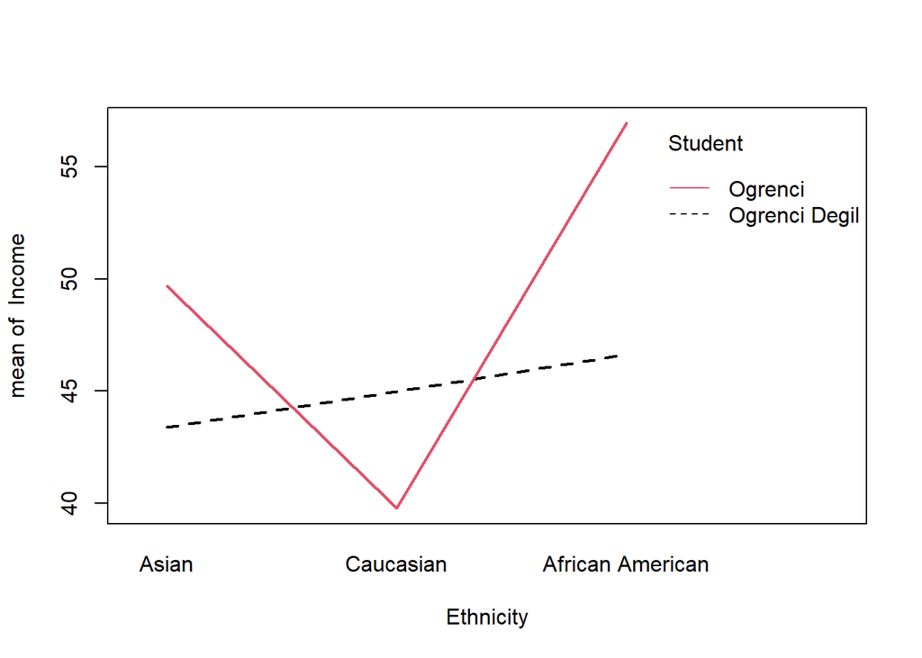

```r
interaction.plot(Ethnicity, Student,Income, fun=mean, type="l", legend=TRUE,col=1:4, lwd=2)
```

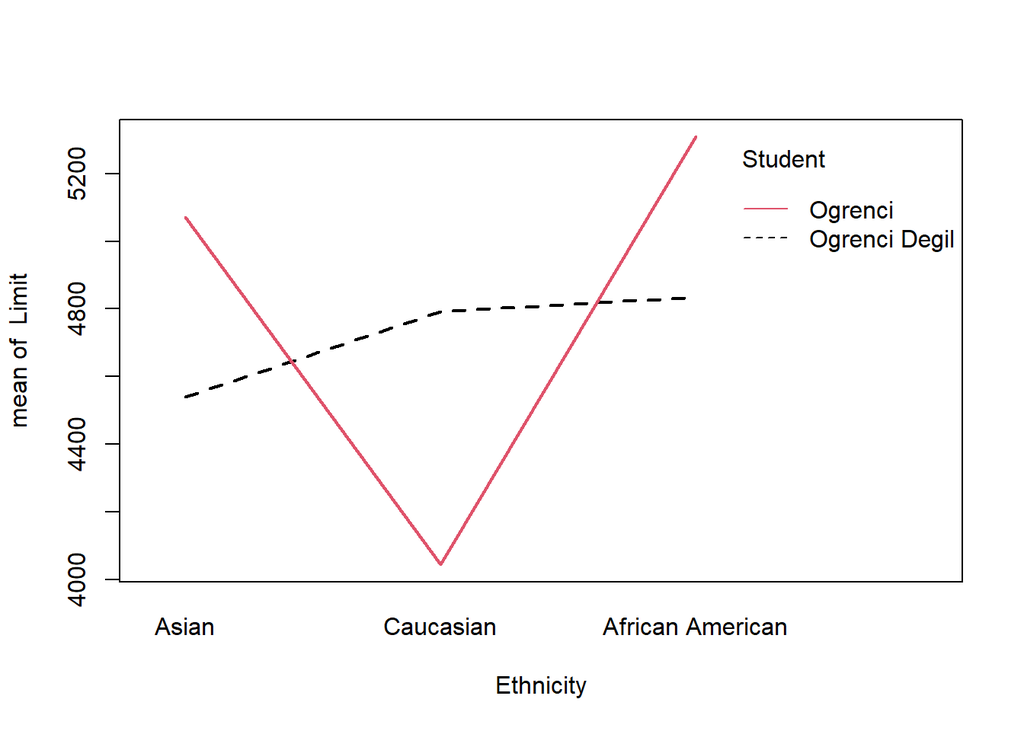

```r
interaction.plot(Ethnicity, Student,Limit, fun=mean, type="l", legend=TRUE,col=1:4, lwd=2)
```

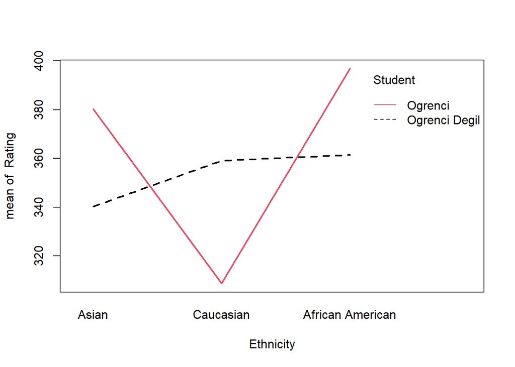

```r
interaction.plot(Ethnicity, Student,Rating, fun=mean, type="l", legend=TRUE,col=1:4, lwd=2)
```

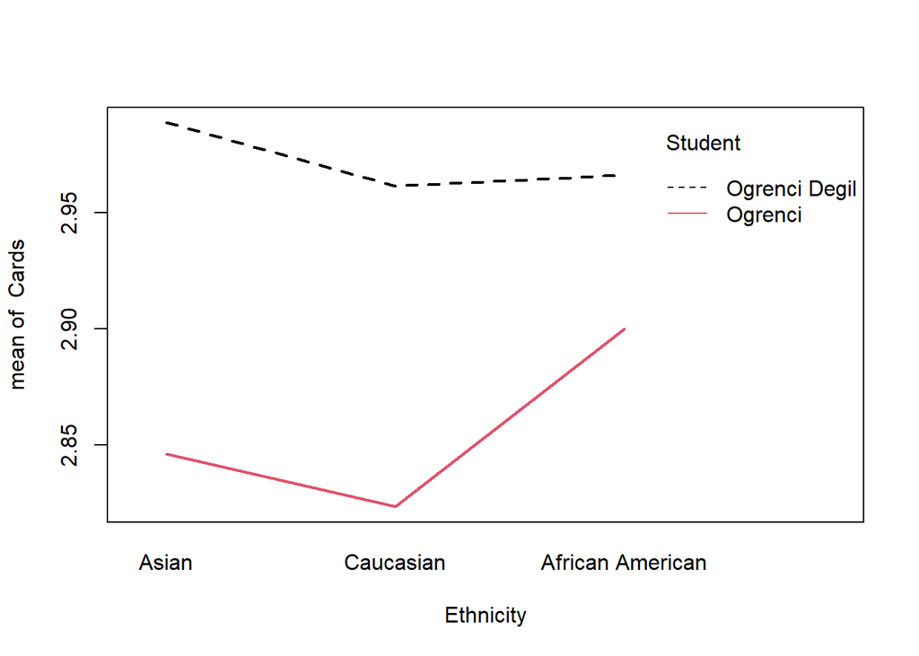

```r
interaction.plot(Ethnicity, Student,Cards, fun=mean, type="l", legend=TRUE,col=1:4, lwd=2)
```

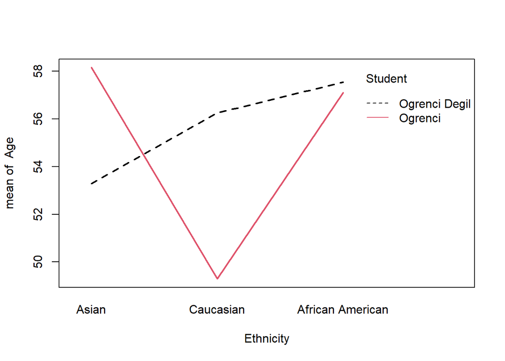

```r
interaction.plot(Ethnicity, Student,Age, fun=mean, type="l", legend=TRUE,col=1:4, lwd=2)
```

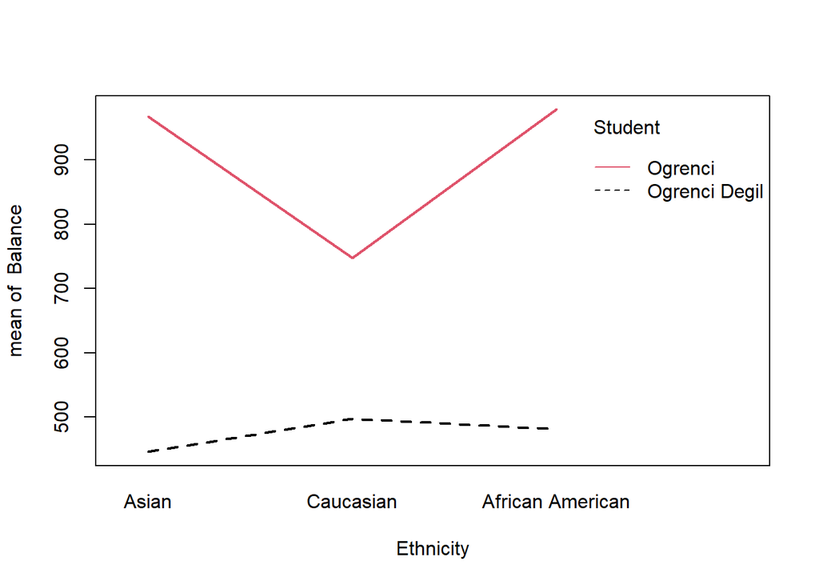

```r
interaction.plot(Ethnicity, Student,Balance, fun=mean, type="l", legend=TRUE,col=1:4, lwd=2)
```

# 4. Temel Bileşenler Analizi

## 4.1 Korelasyon

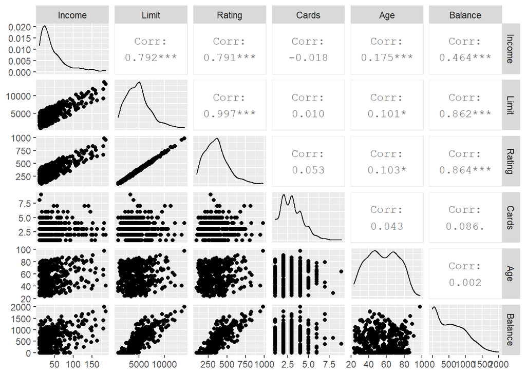

```r
library(GGally)
kor_kredi = kredi[, c(1:5,11)]
ggpairs(kor_kredi)
```

```r
library("Hmisc")
rcorr(as.matrix(kor_kredi),type="pearson")
```

```
##         Income Limit Rating Cards  Age Balance
## Income    1.00  0.79   0.79 -0.02 0.18    0.46
## Limit     0.79  1.00   1.00  0.01 0.10    0.86
## Rating    0.79  1.00   1.00  0.05 0.10    0.86
## Cards    -0.02  0.01   0.05  1.00 0.04    0.09
## Age       0.18  0.10   0.10  0.04 1.00    0.00
## Balance   0.46  0.86   0.86  0.09 0.00    1.00
##
## n= 400
##
##
## P
##         Income Limit  Rating Cards  Age    Balance
## Income         0.0000 0.0000 0.7156 0.0004 0.0000
## Limit   0.0000        0.0000 0.8384 0.0437 0.0000
## Rating  0.0000 0.0000        0.2881 0.0392 0.0000
## Cards   0.7156 0.8384 0.2881        0.3916 0.0842
## Age     0.0004 0.0437 0.0392 0.3916        0.9708
## Balance 0.0000 0.0000 0.0000 0.0842 0.9708
```

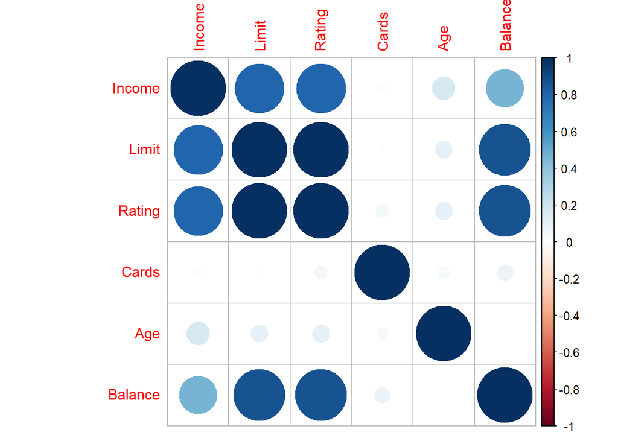

```r
library(corrplot)
corrplot(cor(kor_kredi))
```

## 4.2 Kaiser-Meyer-Olkin (KMO) Örneklem Yeterliliği Ölçüsü ve Bartlett Küresellik Testi

```r
library(psych)
KMO(kor_kredi)
```

```
## Kaiser-Meyer-Olkin factor adequacy
## Call: KMO(r = kor_kredi)
## Overall MSA =  0.66
## MSA for each item =
##  Income   Limit  Rating   Cards     Age Balance
##    0.74    0.66    0.66    0.02    0.80    0.76
```

```r
cortest.bartlett(cor(kor_kredi),nrow(kor_kredi))
```

```
## $chisq
## [1] 3394.141
##
## $p.value
## [1] 0
##
## $df
## [1] 15
```

$H_0$: R=I (Korelayan matrisi birim matrise eşittir)

$H_A$: R≠I (Korelayan matrisi birim matrise eş değildir)

%95 güven düzeyinde temel bileşenler analizine gerek vardır.

KMO değeri %50 nin üzerinde olduğu için veriseti gözlemi uygundur.

```r
fit.pca <- prcomp( ~., data=kor_kredi, scale=TRUE) # korelasyon matrisi icin scale=TRUE yaz
fit.pca$rotation
```

```
##                PC1         PC2          PC3         PC4         PC5
## Income  0.44543902 -0.04477564  0.194710459  0.73913380  0.46404968
## Limit   0.53612269  0.06028782  0.001549746 -0.03406933 -0.45896631
## Rating  0.53670791  0.03251307 -0.030523507 -0.02514062 -0.45539994
## Cards   0.02877892 -0.62995334 -0.759733938  0.15471713 -0.01622738
## Age     0.07824803 -0.76541710  0.585381420 -0.25533473  0.01210941
## Balance 0.46813480  0.10295086 -0.203191258 -0.60229166  0.60515184
##                   PC6
## Income  -0.0024858080
## Limit   -0.7050706669
## Rating   0.7084734910
## Cards   -0.0305645408
## Age     -0.0002075285
## Balance -0.0005037288
```

Değişkenlerin faktör yükleri

```r
as_tibble(fit.pca$x)
```

| PC1 | PC2 | PC3 | PC4 | PC5 | PC6 |
| --- | --- | --- | --- | --- | --- |
| -1.20402390 | 1.35334091 | -0.2762740144 | -0.14997937 | -0.2130003292 | 3.958876e-02 |
| 2.16651763 | -1.10267250 | 1.0127481649 | 0.33951925 | 0.5661079768 | -2.844731e-03 |
| 1.99803239 | -1.12673012 | 0.2144348428 | 0.99689025 | -0.0741915309 | -1.394866e-02 |
| 3.91302946 | 1.01390255 | -0.3753870294 | 1.76580366 | 0.0276808302 | 2.792710e-02 |
| 0.02278977 | -0.15857886 | 1.0911451896 | 0.17793989 | -0.1265588706 | -1.922069e-02 |
| 2.71465486 | -1.19714445 | 0.0206239350 | -0.37520893 | 0.0049983457 | -5.799314e-02 |
| -1.37951090 | 1.17262012 | -0.0786977234 | 0.11106610 | -0.1876359128 | -4.039135e-03 |
| 1.90866502 | -0.80976171 | 1.5535099385 | -0.54432176 | -0.0937547127 | 1.138681e-02 |
| -1.17797586 | -1.46871044 | -0.8241347678 | -0.20224030 | -0.1831517306 | -1.199122e-02 |
| 2.06194667 | 0.86733932 | -0.7707846705 | -0.37629286 | 0.6071797027 | -1.689427e-02 |

[output cut: 390 more lines]

Gözlemlerin faötör yükleri

```r
summary(fit.pca)  #Cumulative Proportion kısmında %66 yı geçen kısma bakılır veya Standard deviation sıkmında 1'in altında düşmeden önceki kısıma bakılır
```

```
## Importance of components:
##                           PC1    PC2    PC3     PC4    PC5     PC6
## Standard deviation     1.8503 1.0164 0.9984 0.70311 0.2232 0.04680
## Proportion of Variance 0.5706 0.1722 0.1661 0.08239 0.0083 0.00037
## Cumulative Proportion  0.5706 0.7428 0.9089 0.99133 0.9996 1.00000
```

Varyans açıklama oranı %66’lık kısmı geçtiği için 2. değer olan %74,280 alınır.

```r
(fit.pca$sdev)^2
```

```
## [1] 3.423772617 1.033028861 0.996831915 0.494360665 0.049815389 0.002190552
```

## 4.3. Faktör Yükleri Grafikleri

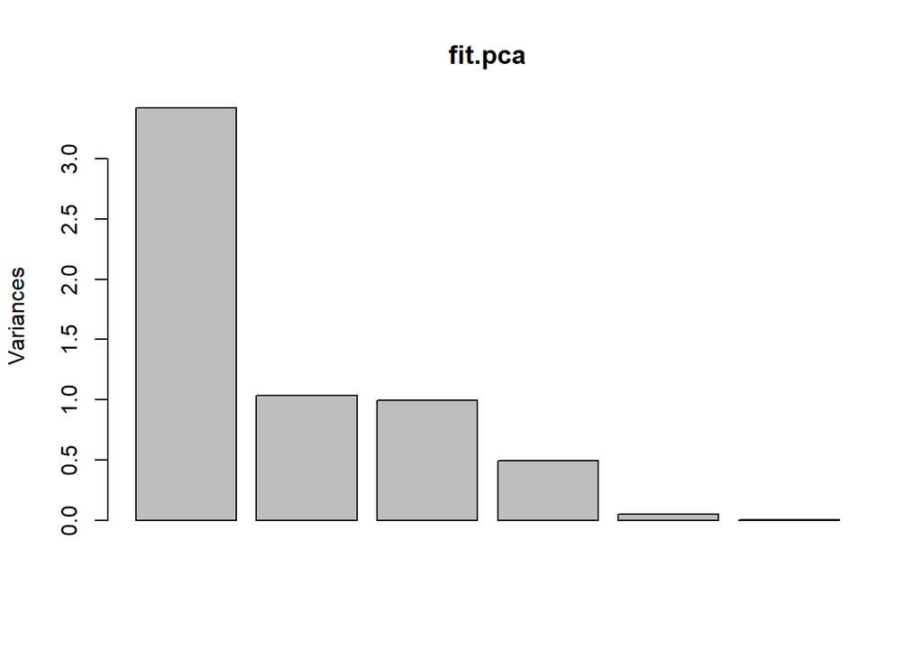

```r
plot(fit.pca)
```

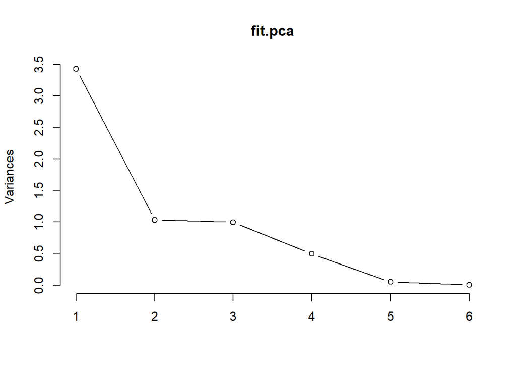

```r
plot(fit.pca,type="line")
```

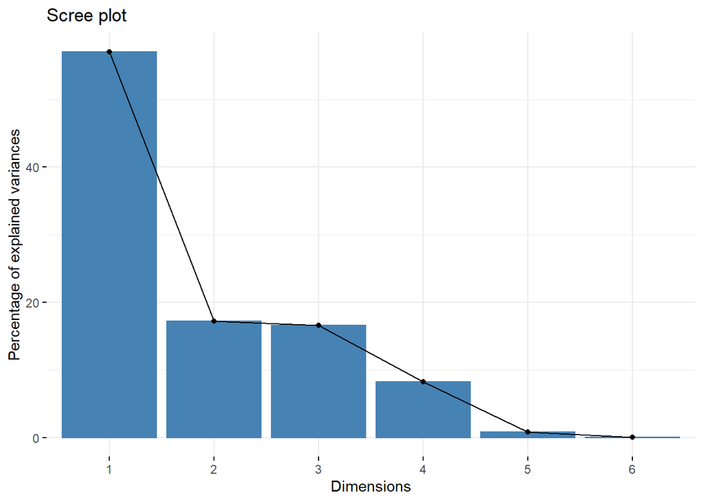

```r
library(factoextra)
scree <- fviz_eig(fit.pca)
scree
```

```r
fit.pca$rotation[,1:2]
```

```
##                PC1         PC2
## Income  0.44543902 -0.04477564
## Limit   0.53612269  0.06028782
## Rating  0.53670791  0.03251307
## Cards   0.02877892 -0.62995334
## Age     0.07824803 -0.76541710
## Balance 0.46813480  0.10295086
```

```r
faktor_yukleri<-t(fit.pca$rotation)*fit.pca$sdev # koklambda ile carpılmıs $H_A$li bu da bizi faktore goturuyor
faktor_yukleri
```

```
##            Income        Limit      Rating        Cards           Age
## PC1  0.8242153804  0.992011356  0.99309421  0.053250907  1.447858e-01
## PC2 -0.0455090746  0.061275353  0.03304565 -0.640272146 -7.779548e-01
## PC3  0.1944017846  0.001547289 -0.03047512 -0.758529532  5.844534e-01
## PC4  0.5196907855 -0.023954411 -0.01767657  0.108782830 -1.795279e-01
## PC5  0.1035729253 -0.102438350 -0.10164236 -0.003621848  2.702742e-03
## PC6 -0.0001163441 -0.032999658  0.03315892 -0.001430522 -9.713028e-06
##           Balance
## PC1  8.662104e-01
## PC2  1.046372e-01
## PC3 -2.028691e-01
## PC4 -4.234760e-01
## PC5  1.350660e-01
## PC6 -2.357619e-05
```

```r
#skorları veriye kaydetme
kredi$comp1=fit.pca$x[,1]
kredi$comp2=fit.pca$x[,2]

#indeks olusturma ###
kredi$index=kredi$comp1+kredi$comp2
indeks<-sort(kredi$index, decreasing = F)
head(indeks)# Gözlem sayısı çok olduğunda kullanılablir.
```

```
## [1] -4.150020 -4.049834 -4.029030 -3.949516 -3.831683 -3.819206
```

## 4.4. Değişkenlerin Faktörler Üzerindeki Dağılım Grafiği

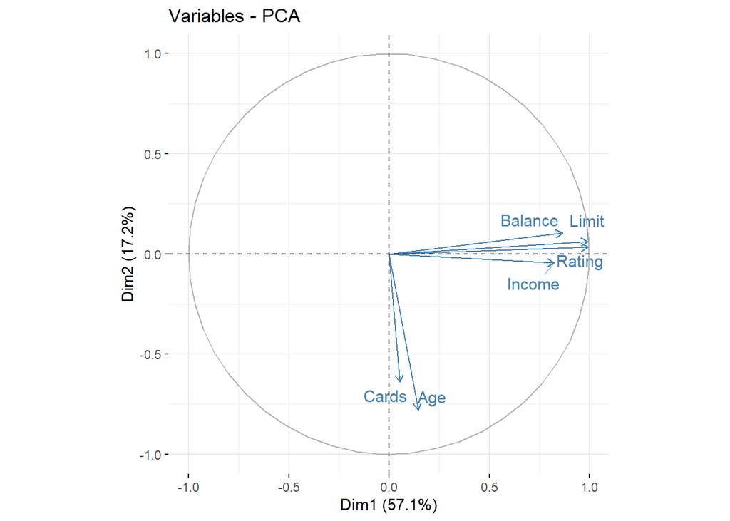

```r
library(factoextra)
fviz_pca_var(fit.pca,col.var="steelblue",
             repel = TRUE )
```

# 5. Faktör Analizi

## 5.1 Korelasyon

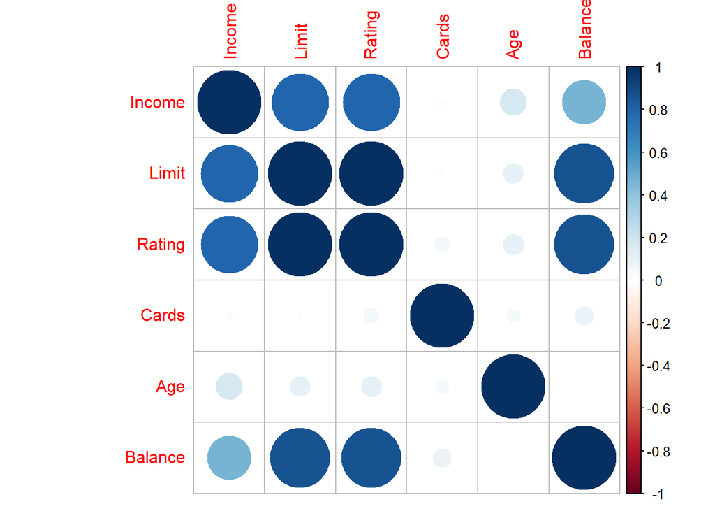

```r
library(corrplot)
library(matlib)
corrplot(cor(kor_kredi))
```

```r
korelasyon<-cor(kor_kredi)
korelasyon
```

```
##              Income      Limit     Rating       Cards         Age     Balance
## Income   1.00000000 0.79208834 0.79137763 -0.01827261 0.175338403 0.463656457
## Limit    0.79208834 1.00000000 0.99687974  0.01023133 0.100887922 0.861697267
## Rating   0.79137763 0.99687974 1.00000000  0.05323903 0.103164996 0.863625161
## Cards   -0.01827261 0.01023133 0.05323903  1.00000000 0.042948288 0.086456347
## Age      0.17533840 0.10088792 0.10316500  0.04294829 1.000000000 0.001835119
## Balance  0.46365646 0.86169727 0.86362516  0.08645635 0.001835119 1.000000000
```

```r
library("Hmisc") #anlamlılık değerleriyle birlikte görmek istersek (2-tailed sonuçlar)
rcorr(as.matrix(kor_kredi),type="pearson")
```

```
##         Income Limit Rating Cards  Age Balance
## Income    1.00  0.79   0.79 -0.02 0.18    0.46
## Limit     0.79  1.00   1.00  0.01 0.10    0.86
## Rating    0.79  1.00   1.00  0.05 0.10    0.86
## Cards    -0.02  0.01   0.05  1.00 0.04    0.09
## Age       0.18  0.10   0.10  0.04 1.00    0.00
## Balance   0.46  0.86   0.86  0.09 0.00    1.00
##
## n= 400
##
##
## P
##         Income Limit  Rating Cards  Age    Balance
## Income         0.0000 0.0000 0.7156 0.0004 0.0000
## Limit   0.0000        0.0000 0.8384 0.0437 0.0000
## Rating  0.0000 0.0000        0.2881 0.0392 0.0000
## Cards   0.7156 0.8384 0.2881        0.3916 0.0842
## Age     0.0004 0.0437 0.0392 0.3916        0.9708
## Balance 0.0000 0.0000 0.0000 0.0842 0.9708
```

```r
invkor<-inv(korelasyon)# korelasyon matrisinin tersi (VIF)
colnames(invkor)<-rownames(invkor)<-colnames(korelasyon) # değişken isimleri yazması için
invkor
```

```
##              Income         Limit       Rating       Cards         Age
## Income   5.52865115   -3.45884284   -5.0213262 -0.00250719 -0.11102086
## Limit   -3.45884284  231.25878425 -223.7522329  9.94318350 -0.05868164
## Rating  -5.02132620 -223.75223292  233.3866869 -9.73682914 -0.19458454
## Cards   -0.00250719    9.94318350   -9.7368291  1.44359583 -0.05968897
## Age     -0.11102086   -0.05868164   -0.1945845 -0.05968897  1.04752275
## Balance  4.75404477   -5.29283309   -5.5815893 -0.28257942  0.27332761
##            Balance
## Income   4.7540448
## Limit   -5.2928331
## Rating  -5.5815893
## Cards   -0.2825794
## Age      0.2733276
## Balance  8.2009064
```

## 5.2 Kaiser-Meyer-Olkin (KMO) Örneklem Yeterliliği Ölçüsü ve Bartlett Küresellik Testi

```r
library(psych)
KMO(kor_kredi)
```

```
## Kaiser-Meyer-Olkin factor adequacy
## Call: KMO(r = kor_kredi)
## Overall MSA =  0.66
## MSA for each item =
##  Income   Limit  Rating   Cards     Age Balance
##    0.74    0.66    0.66    0.02    0.80    0.76
```

```r
cortest.bartlett(cor(kor_kredi),nrow(kor_kredi))
```

```
## $chisq
## [1] 3394.141
##
## $p.value
## [1] 0
##
## $df
## [1] 15
```

$H_0$: R=I (Korelayan matrisi birim matrise eşittir)

$H_A$: R≠I (Korelayan matrisi birim matrise eş değildir)

%95 güven düzeyinde temel bileşenler analizine gerek vardır.

KMO değeri %50 nin üzerinde olduğu için veriseti gözlemi uygundur.

## 5.3 Temel Bilesenler Analizi Yöntemi(Kok lambda yaklasimi) ile Faktör Analizi

```r
fa_kokl<-principal(kor_kredi, nfactors =2, rotate = "none")
fit.pca2 <- prcomp( ~., kor_kredi, scale=TRUE)
print(fa_kokl$loadings, digits=3, cutoff=.0, sort=TRUE)
```

```
##
## Loadings:
##         PC1    PC2
## Income   0.824  0.046
## Limit    0.992 -0.061
## Rating   0.993 -0.033
## Balance  0.866 -0.105
## Cards    0.053  0.640
## Age      0.145  0.778
##
##                  PC1   PC2
## SS loadings    3.424 1.033
## Proportion Var 0.571 0.172
## Cumulative Var 0.571 0.743
```

Varyans açıklama oranı %66’lık kısmı geçtiği için 2. değer olan %74,280 alınır.

```r
fa_kokl$communality
```

```
##    Income     Limit    Rating     Cards       Age   Balance
## 0.6814021 0.9878412 0.9873281 0.4127841 0.6261766 0.7612694
```

```r
fa_kokl$loadings[ , ]^2
```

```
##                 PC1         PC2
## Income  0.679330993 0.002071076
## Limit   0.984086530 0.003754669
## Rating  0.986236109 0.001092015
## Cards   0.002835659 0.409948421
## Age     0.020962917 0.605213731
## Balance 0.750320409 0.010948949
```

```r
rowSums(fa_kokl$loadings[ , ]^2)
```

```
##    Income     Limit    Rating     Cards       Age   Balance
## 0.6814021 0.9878412 0.9873281 0.4127841 0.6261766 0.7612694
```

```r
var_oran<-colSums(fa_kokl$loadings[ , ]^2)/9 #varyans aciklama oranlari
var_oran
```

```
##       PC1       PC2
## 0.3804192 0.1147810
```

```r
sum(var_oran)
```

```
## [1] 0.4952002
```

## 5.4. Faktör Yükleri Grafikleri

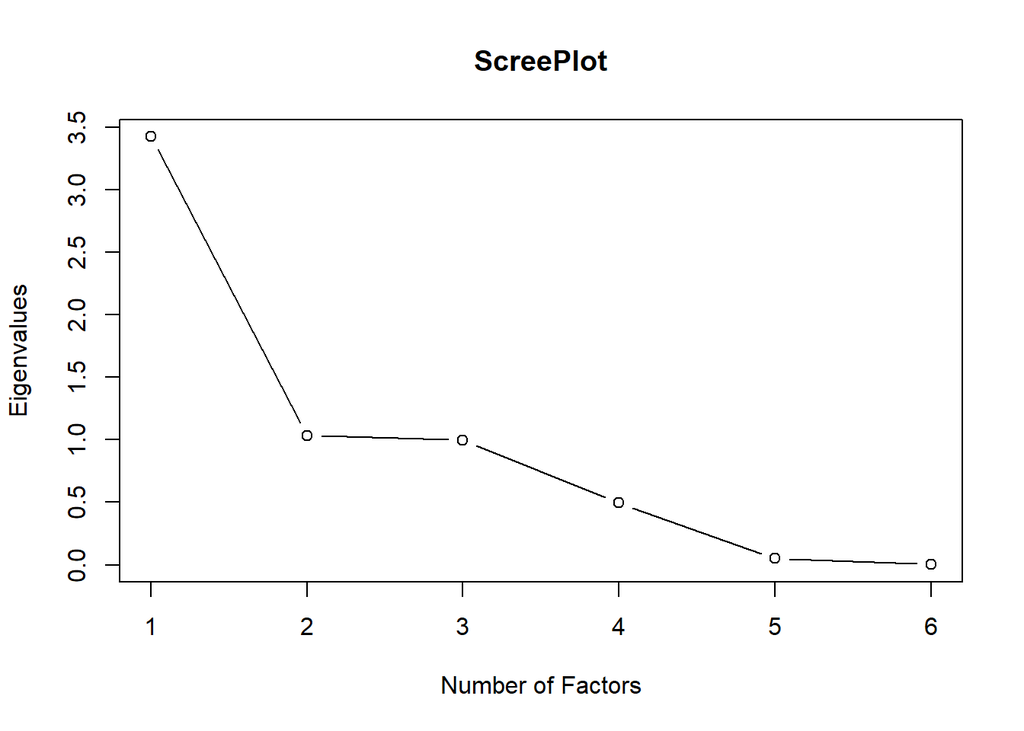

```r
plot(fa_kokl$values, type="b", main="ScreePlot", xlab="Number of Factors", ylab="Eigenvalues")
```

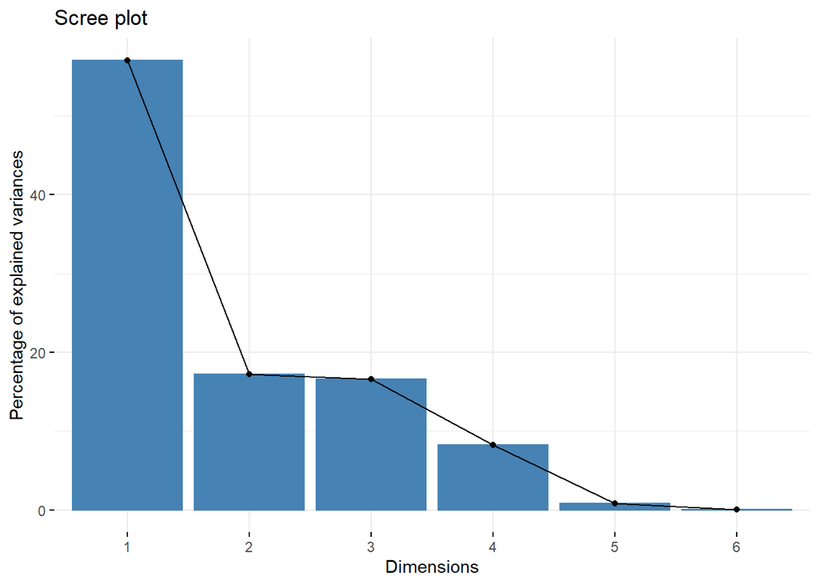

```r
library(factoextra) #109. satıra bağlı bir fonksiyon
scree <- fviz_eig(fit.pca2)
scree
```

```r
artik_kor<-fa_kokl$residual ## Artık korelasyon matrisi
artik_kor
```

```
##              Income        Limit        Rating       Cards          Age
## Income   0.31859793 -0.022754091 -2.564202e-02 -0.09130102  0.020599746
## Limit   -0.02275409  0.012158801  9.694120e-03 -0.00336127  0.004928258
## Rating  -0.02564202  0.009694120  1.267188e-02  0.02151407 -0.014912886
## Cards   -0.09130102 -0.003361270  2.151407e-02  0.58721592 -0.462864500
## Age      0.02059975  0.004928258 -1.491289e-02 -0.46286450  0.373823352
## Balance -0.24552551 -0.004004942 -6.114891e-05  0.10732616 -0.042176774
##               Balance
## Income  -2.455255e-01
## Limit   -4.004942e-03
## Rating  -6.114891e-05
## Cards    1.073262e-01
## Age     -4.217677e-02
## Balance  2.387306e-01
```

```r
length(artik_kor[abs(artik_kor)<0.05])/72
```

```
## [1] 0.3333333
```

```r
fa_kok1<-principal(kor_kredi, nfactors =2, rotate = "varimax")
print(fa_kokl$loadings, kor_krediits=3, cutoff=.3, sort=TRUE)
```

```
##
## Loadings:
##         PC1    PC2
## Income   0.824
## Limit    0.992
## Rating   0.993
## Balance  0.866
## Cards           0.640
## Age             0.778
##
##                  PC1   PC2
## SS loadings    3.424 1.033
## Proportion Var 0.571 0.172
## Cumulative Var 0.571 0.743
```

```r
fa_kok2<-principal(kor_kredi[,-4], nfactors =2, rotate = "varimax")
print(fa_kokl$loadings, digits=3, cutoff=.3, sort=TRUE)
```

```
##
## Loadings:
##         PC1    PC2
## Income   0.824
## Limit    0.992
## Rating   0.993
## Balance  0.866
## Cards           0.640
## Age             0.778
##
##                  PC1   PC2
## SS loadings    3.424 1.033
## Proportion Var 0.571 0.172
## Cumulative Var 0.571 0.743
```

$Z_1$ = 0,992*Limit + 0,993*Kredi Notu + 0,866*Bakiye + 0,824*Gelir

## 5.5. Değişkenlerşn Faktörler Üzerindeki Dağılım Grafiği

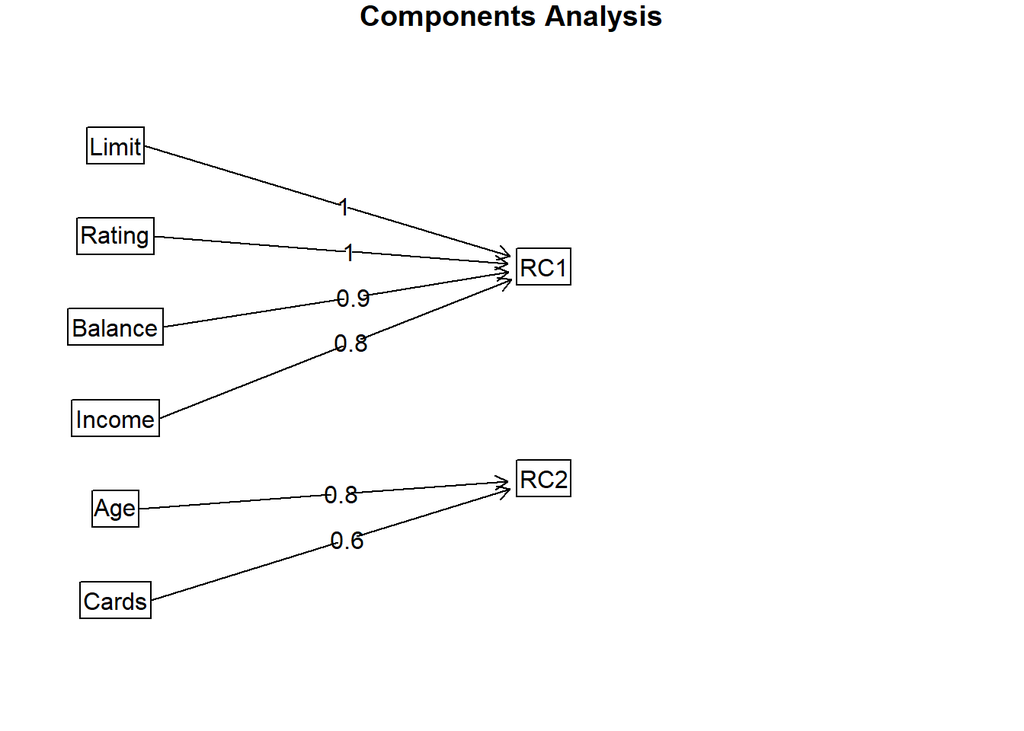

```r
fa.diagram(fa_kok1)
```

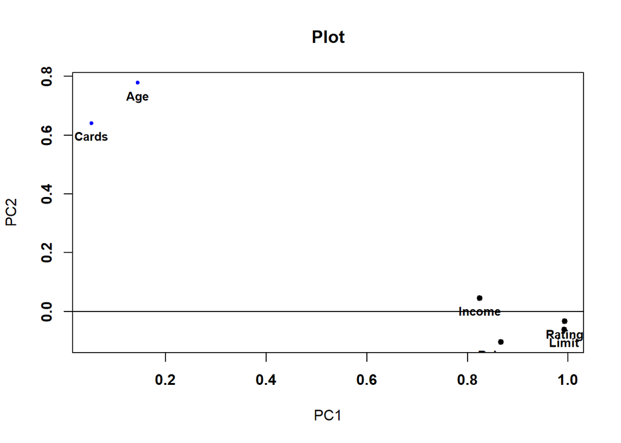

```r
fyuk2=fa_kokl$loadings[,1:2]
factor.plot(fyuk2, cut=0.5, labels=rownames(fa_kokl$loadings),font=2, cex=0.8)
```

# 6. Diskriminant Analizi

## 6.1. Değişkenlerin Korelasyon Grafikleri

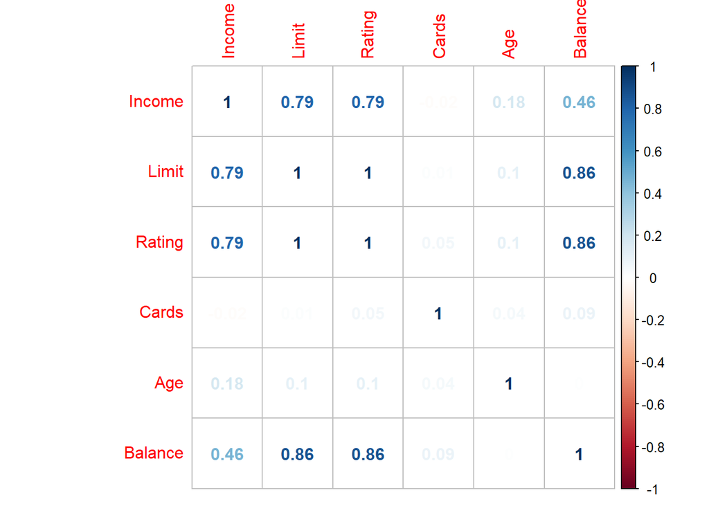

```r
library(corrplot)
corrplot(cor(kredi[,c(1:5,11)]), method="number")
```

Değişken korelasyon değerleri %80 üzerinde ise alınmaz. Korelasyonu yüksek değişkenler çalışmadan çıkartılmıştır.

## 6.2. Değişkenlerin Toplu Normallik İncelemesi

```r
kredi_New = kredi[, c(1,3,4,5,9)]
library(rstatix)
kredi_New %>%
  dplyr::select(!c(Married)) %>%
  mshapiro_test()
```

| statistic | p.value |
| --- | --- |
| 0.9368145 | 5.373027e-12 |

Bütün değişkenlerin sig. değeri 0,05’ten küçük olduğu için $H_0$ reddedilir.

%95 Güven düzeyinde değişkenler normal dağılımdan gelmemektedir.

## 6.3. Box’ın Kovaryans Matrislerinin Eşitliği Testi

```r
boxM(kredi[,c(1:5,11)], kredi$Married)
```

```
##
##  Box's M-test for Homogeneity of Covariance Matrices
##
## data:  kredi[, c(1:5, 11)]
## Chi-Sq (approx.) = 16.302, df = 21, p-value = 0.7524
```

$H_0$: Gruplararası varyans - kovaryans matrisi eşittir

$H_A$: Gruplaraarası göre varyans - kovaryans matrisi eşit değildir.

Sig. değeri 0.05’den büyük olduğu için $H_0$ reddedilmez.

%95 güven düzeyi ile gruplara göre varyans - kovaryans matrisi eşittir.

## 6.4. Ayrınsama Fonksiyonu

```r
library(MASS)
lda_kredi <- lda(Married ~ Income + Rating + Age + Cards, data=kredi_New)
lda_kredi
```

```
## Call:
## lda(Married ~ Income + Rating + Age + Cards, data = kredi_New)
##
## Prior probabilities of groups:
##  Bekar   Evli
## 0.3875 0.6125
##
## Group means:
##         Income   Rating      Age    Cards
## Bekar 43.64109 347.8000 57.25161 2.974194
## Evli  46.21708 359.4571 54.66531 2.946939
##
## Coefficients of linear discriminants:
##                 LD1
## Income  0.011795881
## Rating  0.001187702
## Age    -0.052980024
## Cards  -0.052739836
```

```r
cons<-apply(kredi_New[,-5], 2, mean)
(-cons)%*%(lda_kredi$scaling)
```

```
##           LD1
## [1,] 2.137624
```

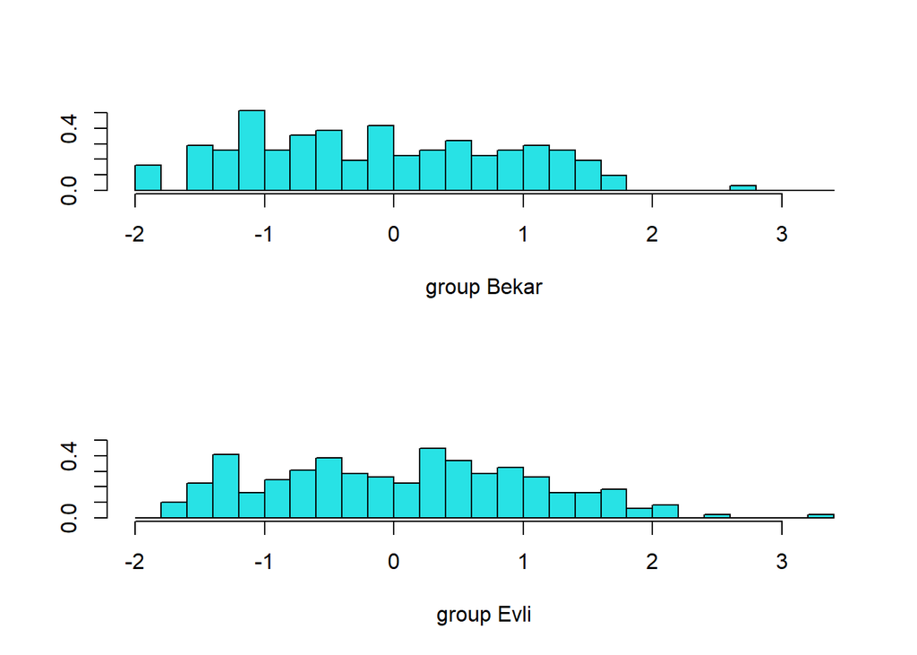

```r
lda.pred <- predict(lda_kredi)
#lda.pred$class # Sinifatamalari

#plots
ldahist(lda.pred$x, g = kredi$Married)
```

```r
tablo<-table(kredi$Married,lda.pred$class)
tablo
```

```
##
##         Bekar Evli
##   Bekar     0  155
##   Evli      0  245
```

Ayrınsama fonksiyonunun atamaları

```r
classrate<-sum(diag(tablo))/sum(tablo)
classrate
```

```
## [1] 0.6125
```

```r
lda_kredi$prior[1]^2 + lda_kredi$prior[2]^2
```

```
##     Bekar
## 0.5253125
```

```r
comp<-cbind(kredi_New$Married,lda.pred$class)
as_tibble(comp)
```

| V1 | V2 |
| --- | --- |
| 2 | 2 |
| 2 | 2 |
| 1 | 2 |
| 1 | 2 |
| 2 | 2 |
| 1 | 2 |
| 1 | 2 |
| 1 | 2 |
| 1 | 2 |
| 2 | 2 |

[output cut: 390 more lines]

Ayrınsama fonksiyonunun atamalarının tamamı

```r
library(klaR)
kredistep<-greedy.wilks(kredi_New[,-5],kredi_New[,5])
summary(kredistep)
```

```
##         Length Class      Mode
## results 6      data.frame list
## formula 3      formula    call
```

## 6.5. Ayrınsama Fonksiyonunun Testi

```r
kredistep$results
```

| vars | Wilks.lambda | F.statistics.overall | p.value.overall | F.statistics.diff | p.value.diff |
| --- | --- | --- | --- | --- | --- |
| Age | 0.9946512 | 2.140271 | 0.1442658 | 2.140271 | 0.1442658 |

$H_0$: Ayrımsama fonksiyonları önemsizdir (Diskirminant önemsiz)

$H_A$: Ayrımsama fonksiyonları önemlidir (Diskirminant önemsiz)

Sig değerleri 0,05’ten büyük olduğu için $H_0$ reddedilmez.

%95 Güven ile ayrınsama fonksiyonu önemli değildir.

# 7. Lojistik Regresyon

## 7.1. Değişkenlerin Eklenmesinin Modele Katkısı

```r
kredi.glm = glm( Gender ~ Income+Limit+Rating+Cards+Age+
                   Education+Student+Married+Ethnicity+Balance,family=binomial, data=kredi)
summary(kredi.glm)
```

```
##
## Call:
## glm(formula = Gender ~ Income + Limit + Rating + Cards + Age +
##     Education + Student + Married + Ethnicity + Balance, family = binomial,
##     data = kredi)
##
## Deviance Residuals:
##     Min       1Q   Median       3Q      Max
## -1.4628  -1.1264  -0.8437   1.1670   1.7550
##
## Coefficients:
##                             Estimate Std. Error z value Pr(>|z|)
## (Intercept)               -4.465e-01  3.347e+01  -0.013    0.989
## Income                     1.060e-02  9.564e-03   1.108    0.268
## Limit                     -1.474e-04  7.104e-04  -0.208    0.836
## Rating                    -2.056e-03  1.028e-02  -0.200    0.841
## Cards                      3.062e-02  9.221e-02   0.332    0.740
## Age                       -7.125e-04  6.229e-03  -0.114    0.909
## Education.L                5.673e+00  2.178e+02   0.026    0.979
## Education.Q               -6.230e+00  2.479e+02  -0.025    0.980
## Education.C                6.062e+00  2.427e+02   0.025    0.980
## Education^4               -5.139e+00  2.131e+02  -0.024    0.981
## Education^5                4.074e+00  1.705e+02   0.024    0.981
## Education^6               -2.886e+00  1.250e+02  -0.023    0.982
## Education^7                2.515e+00  8.399e+01   0.030    0.976
## Education^8               -2.092e+00  5.163e+01  -0.041    0.968
## Education^9                1.365e+00  2.888e+01   0.047    0.962
## Education^10              -9.921e-01  1.459e+01  -0.068    0.946
## Education^11              -1.851e-02  6.585e+00  -0.003    0.998
## Education^12              -1.590e-01  2.621e+00  -0.061    0.952
## Education^13               1.736e-03  9.430e-01   0.002    0.999
## Education^14               3.065e-01  4.185e-01   0.732    0.464
## Education^15               3.617e-01  3.406e-01   1.062    0.288
## StudentOgrenci            -7.626e-01  5.715e-01  -1.334    0.182
## MarriedEvli               -6.835e-02  2.160e-01  -0.316    0.752
## EthnicityCaucasian         1.224e-01  2.548e-01   0.480    0.631
## EthnicityAfrican American  1.340e-01  2.973e-01   0.451    0.652
## Balance                    8.281e-04  1.062e-03   0.780    0.436
##
## (Dispersion parameter for binomial family taken to be 1)
##
##     Null deviance: 554.03  on 399  degrees of freedom
## Residual deviance: 541.13  on 374  degrees of freedom
## AIC: 593.13
##
## Number of Fisher Scoring iterations: 12
```

$H_0$: Değişkenler eklenmesinin modele katkısı yoktur.

$H_A$: Değişkenler eklenmesinin modele katkısı vardır.

Değişkenlerin Sig değerleri 0,05’ten büyük olduğu için $H_0$ reddedilmez.

%95 Güven ile değişkenlerin eklenmesinin modele katkısı yoktur.

```r
names(kredi.glm)
```

```
##  [1] "coefficients"      "residuals"         "fitted.values"
##  [4] "effects"           "R"                 "rank"
##  [7] "qr"                "family"            "linear.predictors"
## [10] "deviance"          "aic"               "null.deviance"
## [13] "iter"              "weights"           "prior.weights"
## [16] "df.residual"       "df.null"           "y"
## [19] "converged"         "boundary"          "model"
## [22] "call"              "formula"           "terms"
## [25] "data"              "offset"            "control"
## [28] "method"            "contrasts"         "xlevels"
```

```r
kredi.glm$coefficients
```

```
##               (Intercept)                    Income                     Limit
##             -0.4464614599              0.0105989256             -0.0001474362
##                    Rating                     Cards                       Age
##             -0.0020558272              0.0306221579             -0.0007124965
##               Education.L               Education.Q               Education.C
##              5.6728374653             -6.2303981710              6.0619344274
##               Education^4               Education^5               Education^6
##             -5.1385233629              4.0743152417             -2.8860180629
##               Education^7               Education^8               Education^9
##              2.5150337708             -2.0923933175              1.3651745223
##              Education^10              Education^11              Education^12
##             -0.9921038603             -0.0185118656             -0.1589992768
##              Education^13              Education^14              Education^15
##              0.0017362515              0.3064869980              0.3616797196
##            StudentOgrenci               MarriedEvli        EthnicityCaucasian
##             -0.7625866483             -0.0683467203              0.1224133193
## EthnicityAfrican American                   Balance
##              0.1339571829              0.0008280554
```

## 7.2. Ki-kare İstatistginin Hesabi

```r
kredi.glm$deviance
```

```
## [1] 541.1267
```

```r
kredi.glm$null.deviance
```

```
## [1] 554.0276
```

```r
kikare<- kredi.glm$null.deviance-kredi.glm$deviance
kikare
```

```
## [1] 12.90092
```

## 7.3. Serbestlik Derecesinin Hesaplanması

```r
kredi.glm$df.null
```

```
## [1] 399
```

```r
kredi.glm$df.residual
```

```
## [1] 374
```

```r
df<-kredi.glm$df.null-kredi.glm$df.residual
df
```

```
## [1] 25
```

```r
kikare.p<- 1 - pchisq(kikare,df)
kikare.p
```

```
## [1] 0.9776926
```

```r
library(ResourceSelection)
```

```
## ResourceSelection 0.3-5   2019-07-22
```

```r
hoslem.test(kredi.glm$y,fitted(kredi.glm))
```

```
##
##  Hosmer and Lemeshow goodness of fit (GOF) test
##
## data:  kredi.glm$y, fitted(kredi.glm)
## X-squared = 8.2645, df = 8, p-value = 0.4081
```

$H_0$: Oluşturulan model veri ile uyumludur

$H_A$: Oluşturulan model veri ile uyumlu değildir.

Sig. değeri 0,05’den büyük olduğu için $H_0$ reddedilmez

%95 Güven ile oluşturulan model veri ile uyumludur.

## 7.4. Modelin $R^2$ degerleri

### 7.4.1. CoxSnell Nagelkerke

```r
library("DescTools")
PseudoR2(kredi.glm, which = c("CoxSnell","Nagelkerke"))
```

```
##   CoxSnell Nagelkerke
## 0.03173775 0.04233429
```

Denenen diğer modeller arasında $R^2$’si en yüksek olan metot seçilmiştir

## 7.5. Lojistik Regresyon Modeli

```r
exp(coef(kredi.glm))
```

```
##               (Intercept)                    Income                     Limit
##              6.398884e-01              1.010655e+00              9.998526e-01
##                    Rating                     Cards                       Age
##              9.979463e-01              1.031096e+00              9.992878e-01
##               Education.L               Education.Q               Education.C
##              2.908587e+02              1.968668e-03              4.292049e+02
##               Education^4               Education^5               Education^6
##              5.866346e-03              5.881020e+01              5.579795e-02
##               Education^7               Education^8               Education^9
##              1.236703e+01              1.233915e-01              3.916406e+00
##              Education^10              Education^11              Education^12
##              3.707958e-01              9.816584e-01              8.529970e-01
##              Education^13              Education^14              Education^15
##              1.001738e+00              1.358644e+00              1.435739e+00
##            StudentOgrenci               MarriedEvli        EthnicityCaucasian
##              4.664583e-01              9.339366e-01              1.130221e+00
## EthnicityAfrican American                   Balance
##              1.143344e+00              1.000828e+00
```

```r
exp(confint.default(kredi.glm,level = 0.95))
```

```
##                                   2.5 %        97.5 %
## (Intercept)                2.063746e-29  1.984048e+28
## Income                     9.918878e-01  1.029778e+00
## Limit                      9.984615e-01  1.001246e+00
## Rating                     9.780479e-01  1.018250e+00
## Cards                      8.606169e-01  1.235345e+00
## Age                        9.871613e-01  1.011563e+00
## Education.L               1.234625e-183 6.852181e+187
## Education.Q               1.733998e-214 2.235097e+208
## Education.C               1.171258e-204 1.572812e+209
## Education^4               2.192400e-184 1.569696e+179
## Education^5               4.009755e-144 8.625562e+146
## Education^6               2.233274e-108 1.394102e+105
## Education^7                3.965724e-71  3.856632e+72
## Education^8                1.402186e-45  1.085837e+43
## Education^9                1.015993e-24  1.509680e+25
## Education^10               1.401711e-13  9.808694e+11
## Education^11               2.435681e-06  3.956401e+05
## Education^12               5.009194e-03  1.452537e+02
## Education^13               1.577717e-01  6.360320e+00
## Education^14               5.982250e-01  3.085650e+00
## Education^15               7.364457e-01  2.799048e+00
## StudentOgrenci             1.521823e-01  1.429754e+00
## MarriedEvli                6.115298e-01  1.426321e+00
## EthnicityCaucasian         6.859505e-01  1.862233e+00
## EthnicityAfrican American  6.384815e-01  2.047413e+00
## Balance                    9.987472e-01  1.002914e+00
```

Değişkenlilerin %95 ile güven aralıkları

## 7.6. Atamalar Tablosu

### 7.6.1. Atama Tablosu

```r
genderpred<-fitted(kredi.glm)
thresh  <- 0.5
genderfac<- cut(genderpred, breaks=c(-Inf, thresh, Inf), labels=c("Kadin", "Erkek"))
cTab <- table(kredi$Gender, genderfac)
cTab
```

```
##        genderfac
##         Kadin Erkek
##   Kadin   129    78
##   Erkek    94    99
```

Kadınlarının cinsiyetinin %62,3’ünü doğru atamıştır.

Erkeklerin cinsiyetinin %51,3’ünü doğru atamıştır.

### 7.6.2. Toplam Dogru Atanma Yüzdesi

```r
sum(diag(cTab)) / sum(cTab)
```

```
## [1] 0.57
```

Toplam cinsiyet atamalarının %57,0’sini doğru yapmıştır.

### 7.6.3. Atama Tablosu Görselleştirilmesi

```r
library(cvms)
library(ggplot2)
library(broom)    # tidy()
library(tibble)   # tibble()
datatib <- tibble("target" = kredi$Gender,"prediction" = genderfac)
datatib
```

| target | prediction |
| --- | --- |
| Erkek | Kadin |
| Kadin | Kadin |
| Erkek | Kadin |
| Kadin | Kadin |
| Erkek | Erkek |
| Erkek | Erkek |
| Kadin | Kadin |
| Erkek | Erkek |
| Kadin | Kadin |
| Kadin | Kadin |

[output cut: 390 more lines]

```r
basic_table <- table(datatib)
basic_table
```

```
##        prediction
## target  Kadin Erkek
##   Kadin   129    78
##   Erkek    94    99
```

```r
cfm <- tidy(basic_table)
cfm
```

| target | prediction | n |
| --- | --- | --- |
| Kadin | Kadin | 129 |
| Erkek | Kadin | 94 |
| Kadin | Erkek | 78 |
| Erkek | Erkek | 99 |

Modelin atamasındaki dağılım

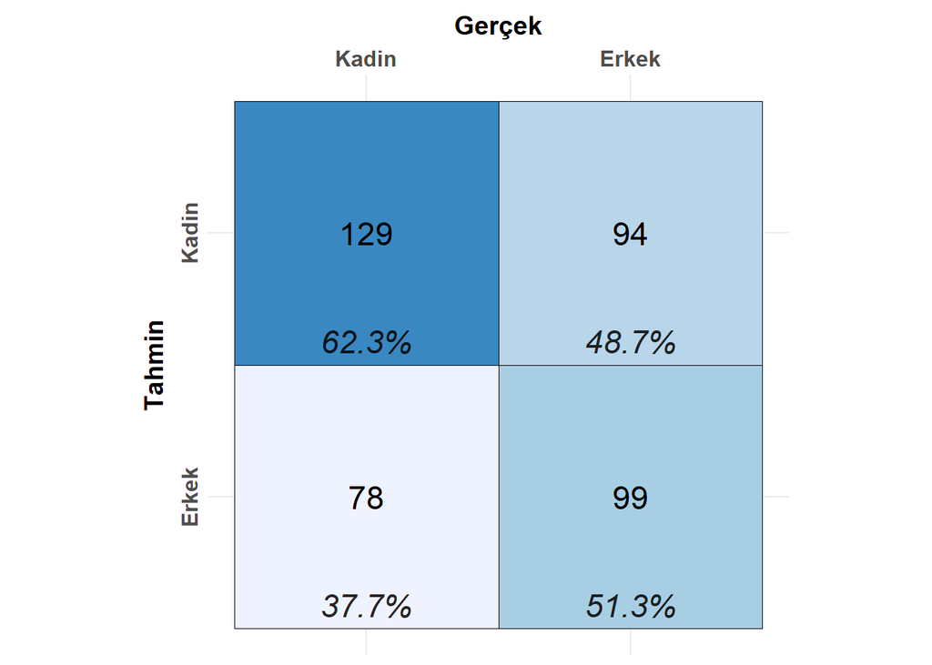

```r
plot_confusion_matrix(cfm,
                      target_col = "target",
                      prediction_col = "prediction",
                      counts_col = "n",
                      add_normalized = FALSE,
                      add_row_percentages = FALSE,
                      font_col_percentages= font(size = 6),
                      font_counts = font(size = 6),
                      tile_border_color = "black")+
                      xlab("Gerçek")+
                      ylab("Tahmin")+
                      theme(axis.text=element_text(size=12,face="bold"),axis.title=element_text(size=14,face="bold"))
```

# 8. Çoklu Lojistik Regresyon

## 8.1. Değişkenlerin Model İçin Anlamlılığı

```r
levels(kredi$Ethnicity)
```

```
## [1] "Asian"            "Caucasian"        "African American"
```

```r
library(mlogit)

ml.data <- mlogit.data(kredi, choice="Ethnicity", shape="wide")
loj_kredi <- mlogit(Ethnicity ~ 0 |Income+Limit+Rating+Cards+Age+Balance+Gender +Student + Married, data=ml.data, reflevel = 'Asian')
summary(loj_kredi)
```

```
##
## Call:
## mlogit(formula = Ethnicity ~ 0 | Income + Limit + Rating + Cards +
##     Age + Balance + Gender + Student + Married, data = ml.data,
##     reflevel = "Asian", method = "nr")
##
## Frequencies of alternatives:choice
##            Asian African American        Caucasian
##           0.2550           0.2475           0.4975
##
## nr method
## 4 iterations, 0h:0m:0s
## g'(-H)^-1g = 0.00046
## successive function values within tolerance limits
##
## Coefficients :
##                                    Estimate  Std. Error z-value Pr(>|z|)
## (Intercept):African American    -1.72046477  1.06763545 -1.6115  0.10708
## (Intercept):Caucasian           -0.20249395  0.88307578 -0.2293  0.81863
## Income:African American         -0.01552507  0.01358717 -1.1426  0.25319
## Income:Caucasian                -0.00844209  0.01114143 -0.7577  0.44862
## Limit:African American          -0.00078991  0.00099562 -0.7934  0.42755
## Limit:Caucasian                 -0.00095066  0.00084796 -1.1211  0.26224
## Rating:African American          0.02011021  0.01436705  1.3997  0.16159
## Rating:Caucasian                 0.01779285  0.01242373  1.4322  0.15210
## Cards:African American          -0.07301049  0.12818199 -0.5696  0.56896
## Cards:Caucasian                 -0.09279121  0.10962397 -0.8465  0.39730
## Age:African American             0.00915016  0.00858023  1.0664  0.28623
## Age:Caucasian                    0.00506510  0.00736017  0.6882  0.49134
## Balance:African American        -0.00182456  0.00148970 -1.2248  0.22066
## Balance:Caucasian               -0.00065942  0.00123141 -0.5355  0.59230
## GenderErkek:African American     0.14519825  0.28791787  0.5043  0.61405
## GenderErkek:Caucasian            0.10284216  0.24693696  0.4165  0.67707
## StudentOgrenci:African American  0.40435409  0.78275568  0.5166  0.60545
## StudentOgrenci:Caucasian        -0.23579409  0.65240534 -0.3614  0.71778
## MarriedEvli:African American    -0.74001102  0.30013430 -2.4656  0.01368 *
## MarriedEvli:Caucasian           -0.35728922  0.26398840 -1.3534  0.17592
## ---
## Signif. codes:  0 '***' 0.001 '**' 0.01 '*' 0.05 '.' 0.1 ' ' 1
##
## Log-Likelihood: -409.7
## McFadden R^2:  0.016465
## Likelihood ratio test : chisq = 13.717 (p.value = 0.74732)
```

$H_0$: Değişkenler modele anlamlı bir katkı sağlamamaktadır.

$H_A$: Değişkenler modele anlamlı bir katkı sağlamaktadır.

Sig. değeri 0,05’den büyük olduğu için $H_0$ Reddedilmez

%95 güven ile değişkenler model için anlamlı değildir.

```r
exp(loj_kredi$coefficients)
```

```
##    (Intercept):African American           (Intercept):Caucasian
##                       0.1789829                       0.8166914
##         Income:African American                Income:Caucasian
##                       0.9845948                       0.9915934
##          Limit:African American                 Limit:Caucasian
##                       0.9992104                       0.9990498
##         Rating:African American                Rating:Caucasian
##                       1.0203138                       1.0179521
##          Cards:African American                 Cards:Caucasian
##                       0.9295911                       0.9113838
##            Age:African American                   Age:Caucasian
##                       1.0091922                       1.0050779
##        Balance:African American               Balance:Caucasian
##                       0.9981771                       0.9993408
##    GenderErkek:African American           GenderErkek:Caucasian
##                       1.1562688                       1.1083165
## StudentOgrenci:African American        StudentOgrenci:Caucasian
##                       1.4983344                       0.7899433
##    MarriedEvli:African American           MarriedEvli:Caucasian
##                       0.4771087                       0.6995701
## attr(,"names.sup.coef")
## character(0)
## attr(,"fixed")
##    (Intercept):African American           (Intercept):Caucasian
##                           FALSE                           FALSE
##         Income:African American                Income:Caucasian
##                           FALSE                           FALSE
##          Limit:African American                 Limit:Caucasian
##                           FALSE                           FALSE
##         Rating:African American                Rating:Caucasian
##                           FALSE                           FALSE
##          Cards:African American                 Cards:Caucasian
##                           FALSE                           FALSE
##            Age:African American                   Age:Caucasian
##                           FALSE                           FALSE
##        Balance:African American               Balance:Caucasian
##                           FALSE                           FALSE
##    GenderErkek:African American           GenderErkek:Caucasian
##                           FALSE                           FALSE
## StudentOgrenci:African American        StudentOgrenci:Caucasian
##                           FALSE                           FALSE
##    MarriedEvli:African American           MarriedEvli:Caucasian
##                           FALSE                           FALSE
## attr(,"sup")
## character(0)
```